# Systems Serology — Concurrent Within-Visit Associations

Focused endpoint-parameterized driver · SBA · WT_IgG · PTNA · maternal-arm primary (TdaP vs TT)

Scot Zens and Anja Saso

2026-07-04

# SBA: Concurrent Within-Visit Antibody Analysis

This is a **focused, expanded extract** of the full config-driven serology pipeline. It runs **only the concurrent (within-visit) association layer** for the infant’s **serum bactericidal activity** (WHOLE_SBA), **restricted to the 8-week infant timepoint (InfMon2)**, and it now covers the expanded feature set — FIM plus the FcγR binding and antigen-specific effector functions — on the untransformed (raw) log assay values. The total-IgG-standardised mode is deferred. The maternal-chain, clinical, and other pipeline parts are excluded.

The endpoint is set once (`params$endpoint = "SBA"`); switching to `WT_IgG` or `PTNA` is a one-line change to that parameter (or use the `render_concurrent_all()` helper in the appendix to knit all three at once).

**Visit naming.** All visits are recoded for clarity throughout: P02→PregEarly, P09→MatBirth, M00→CordBlood, M02→InfMon2, M04→InfMon4, M05→InfMon5, M09→InfMon9. This analysis is restricted to the **8-week infant timepoint (InfMon2)**.

**Stratification.** Primary axis is the **maternal vaccination arm (TdaP vs TT)**; within each, results are reported pooled across infant arms and separately for each infant priming level (aP, wP).

**Downstream use.** The knitted **HTML** is intended for the summary engine; the **Word** document is for the analysis recipient. Inline “🧭 Maps to interpretation” callouts tie each block to the matching section of the written concurrent-analysis summary for this endpoint.

# Concurrent Within-Visit Architecture (Expanded)

This part models the infant’s **SBA** against antibody features **measured at the same infant visit**, restricted to the **8-week timepoint (InfMon2)**. Relative to the original version it adds the **FIM** antigen, the **FcγR binding** features (FcgR2a, FcgR3b), and the **antigen-specific effector functions** (ADCD for all six antigens; ADCP and ADNP for PT/PRN/DT/TT only), on the **untransformed (raw) log assay values**. The total-IgG-standardised mode is deferred and not run here.

**Stratification is maternal-arm primary** (TdaP / TT), with infant splits (aP, wP) nested. Networks / NCT need ≥ 30 complete cases; underpowered cells are skipped and recorded in the participant accounting. Execution is staged (cheap → expensive) with live console logging.

## STAGE 1 — Data Preparation and Coverage

```r
.stage(1, N_STAGES, "data preparation + coverage")
wide_by_mode  <- list()
strata_by_mode <- list()
for (md in DATA_MODES) {
  dw <- prep_mode(md)
  wide_by_mode[[md]]   <- dw
  strata_by_mode[[md]] <- build_maternal_strata(dw)
  .info("mode=%-7s wide = %d rows \u00d7 %d cols", md, nrow(dw), ncol(dw))
  cat(sprintf("**Mode `%s`** — %d subjects \u00d7 %d columns at %s.  \n",
              md, nrow(dw), ncol(dw), CONC_VISIT))
  cnt <- as.data.frame(table(dw$arm_name), stringsAsFactors = FALSE)
  colnames(cnt) <- c("Maternal arm", "n_subjects")
  knitr::kable(cnt, caption = sprintf("Subjects by maternal arm (mode = %s, %s).",
                                      md, CONC_VISIT)) %>% print()
  cat("\n")
}
```

**Mode `raw`** — 287 subjects × 55 columns at InfMon2.

Subjects by maternal arm (mode = raw, InfMon2).

| Maternal arm | n_subjects |
| --- | --- |
| TdaP | 141 |
| TT | 146 |

```r
.mark("stage1_prep")
```

## STAGE 2 — Regression Layer (relative importance + ratios)

```r
.stage(2, N_STAGES, "regression / relative importance / ratios")
conc_by_mode <- list()
for (md in DATA_MODES) {
  cat("\n## Mode: `", md, "`\n\n", sep = "")
  sx <- strata_by_mode[[md]]
  conc <- lapply(names(sx), function(k) {
    r <- run_blocks_x(sx[[k]]$data, stratum = sx[[k]]$label, mode = md)
    .info("mode=%-7s stratum=%-26s blocks fitted", md, sx[[k]]$label)
    r
  })
  names(conc) <- names(sx)
  conc_by_mode[[md]] <- conc
  for (m in cfg$maternal_arms) {
    cat("### ", m, " mothers\n\n", sep = "")
    show_stratum_blocks(conc[[m]], full = TRUE)
    for (i in cfg$infant_arms) {
      key <- paste0(m, "_", i)
      if (!is.null(conc[[key]])) {
        cat("#### ", sx[[key]]$label, "\n\n", sep = "")
        show_stratum_blocks(conc[[key]], full = FALSE)
      }
    }
  }
}
```

## Mode: `raw`

### TdaP mothers

**n = 105 | R² = 0.874 | adj-R² = 0.867 | p<sub>model</sub> = 7.33e-42**

Coefficients — Antigen totals (6) [raw]

| Predictor | β | SE | t | p |  |
| --- | --- | --- | --- | --- | --- |
| (Intercept) | 0.3991 | 0.2132 | 1.8717 | 0.0642 | ns |
| PT_IgG | -0.0856 | 0.0877 | -0.9768 | 0.3310 | ns |
| FHA_IgG | -0.1083 | 0.1114 | -0.9717 | 0.3340 | ns |
| PRN_IgG | 0.9906 | 0.0432 | 22.9283 | 0.0000 | *** |
| DT_IgG | 0.0603 | 0.0705 | 0.8560 | 0.3940 | ns |
| TT_IgG | 0.0642 | 0.1071 | 0.5992 | 0.5500 | ns |
| FIM_IgG | 0.1063 | 0.0473 | 2.2498 | 0.0267 | * |

Relative importance (lmg) — Antigen totals (6) [raw]

|  | Predictor | lmg (%) |
| --- | --- | --- |
| PRN_IgG | PRN_IgG | 74.69 |
| PT_IgG | PT_IgG | 5.46 |
| FHA_IgG | FHA_IgG | 3.80 |
| FIM_IgG | FIM_IgG | 1.86 |
| DT_IgG | DT_IgG | 1.43 |
| TT_IgG | TT_IgG | 0.19 |

**n = 104 | R² = 0.117 | adj-R² = 0.081 | p<sub>model</sub> = 0.0146**

Coefficients — PT subclasses [raw]

| Predictor | β | SE | t | p |  |
| --- | --- | --- | --- | --- | --- |
| (Intercept) | -0.0511 | 1.2646 | -0.0404 | 0.96800 | ns |
| PT_IgG1 | 0.6276 | 0.2242 | 2.7992 | 0.00616 | ** |
| PT_IgG2 | 0.0009 | 0.8148 | 0.0011 | 0.99900 | ns |
| PT_IgG3 | 0.2528 | 0.7277 | 0.3474 | 0.72900 | ns |
| PT_IgG4 | -0.1604 | 0.8012 | -0.2002 | 0.84200 | ns |

Relative importance (lmg) — PT subclasses [raw]

|  | Predictor | lmg (%) |
| --- | --- | --- |
| PT_IgG1 | PT_IgG1 | 9.12 |
| PT_IgG2 | PT_IgG2 | 2.16 |
| PT_IgG3 | PT_IgG3 | 0.20 |
| PT_IgG4 | PT_IgG4 | 0.20 |

**n = 104 | R² = 0.110 | adj-R² = 0.074 | p<sub>model</sub> = 0.0205**

Coefficients — FHA subclasses [raw]

| Predictor | β | SE | t | p |  |
| --- | --- | --- | --- | --- | --- |
| (Intercept) | -0.4938 | 0.7126 | -0.6929 | 0.4900 | ns |
| FHA_IgG1 | 0.4062 | 0.1848 | 2.1977 | 0.0303 | * |
| FHA_IgG2 | 0.0466 | 0.1942 | 0.2399 | 0.8110 | ns |
| FHA_IgG3 | 0.2621 | 0.2416 | 1.0848 | 0.2810 | ns |
| FHA_IgG4 | 0.0860 | 0.1211 | 0.7101 | 0.4790 | ns |

Relative importance (lmg) — FHA subclasses [raw]

|  | Predictor | lmg (%) |
| --- | --- | --- |
| FHA_IgG1 | FHA_IgG1 | 5.54 |
| FHA_IgG3 | FHA_IgG3 | 2.94 |
| FHA_IgG4 | FHA_IgG4 | 1.81 |
| FHA_IgG2 | FHA_IgG2 | 0.66 |

**n = 104 | R² = 0.804 | adj-R² = 0.797 | p<sub>model</sub> = 3.33e-34**

Coefficients — PRN subclasses [raw]

| Predictor | β | SE | t | p |  |
| --- | --- | --- | --- | --- | --- |
| (Intercept) | -1.5395 | 0.3126 | -4.9246 | 3.40e-06 | *** |
| PRN_IgG1 | 1.0937 | 0.0772 | 14.1714 | 0.00e+00 | *** |
| PRN_IgG2 | 0.0560 | 0.2100 | 0.2667 | 7.90e-01 | ns |
| PRN_IgG3 | 0.1737 | 0.1643 | 1.0572 | 2.93e-01 | ns |
| PRN_IgG4 | 0.0875 | 0.1165 | 0.7510 | 4.54e-01 | ns |

Relative importance (lmg) — PRN subclasses [raw]

|  | Predictor | lmg (%) |
| --- | --- | --- |
| PRN_IgG1 | PRN_IgG1 | 58.16 |
| PRN_IgG2 | PRN_IgG2 | 17.16 |
| PRN_IgG3 | PRN_IgG3 | 4.48 |
| PRN_IgG4 | PRN_IgG4 | 0.66 |

**n = 104 | R² = 0.080 | adj-R² = 0.043 | p<sub>model</sub> = 0.0804**

Coefficients — FIM subclasses [raw]

| Predictor | β | SE | t | p |  |
| --- | --- | --- | --- | --- | --- |
| (Intercept) | -0.1770 | 1.2795 | -0.1383 | 0.8900 | ns |
| FIM_IgG1 | -0.0145 | 0.1713 | -0.0849 | 0.9330 | ns |
| FIM_IgG2 | 0.5172 | 0.3026 | 1.7095 | 0.0905 | ns |
| FIM_IgG3 | 0.3409 | 0.3252 | 1.0481 | 0.2970 | ns |
| FIM_IgG4 | 0.5491 | 1.0075 | 0.5450 | 0.5870 | ns |

Relative importance (lmg) — FIM subclasses [raw]

|  | Predictor | lmg (%) |
| --- | --- | --- |
| FIM_IgG2 | FIM_IgG2 | 4.40 |
| FIM_IgG3 | FIM_IgG3 | 2.05 |
| FIM_IgG1 | FIM_IgG1 | 1.08 |
| FIM_IgG4 | FIM_IgG4 | 0.46 |

**n = 104 | R² = 0.852 | adj-R² = 0.832 | p<sub>model</sub> = 1.92e-32**

Coefficients — FcγR binding (all antigens) [raw]

| Predictor | β | SE | t | p |  |
| --- | --- | --- | --- | --- | --- |
| (Intercept) | -0.1369 | 1.1027 | -0.1241 | 9.01e-01 | ns |
| PT_FcgR2a | 0.0841 | 0.1662 | 0.5063 | 6.14e-01 | ns |
| PT_FcgR3b | -0.1957 | 0.1542 | -1.2689 | 2.08e-01 | ns |
| FHA_FcgR2a | -0.9091 | 0.2070 | -4.3906 | 3.04e-05 | *** |
| FHA_FcgR3b | 0.1082 | 0.1202 | 0.9002 | 3.70e-01 | ns |
| PRN_FcgR2a | 0.6651 | 0.1050 | 6.3359 | 0.00e+00 | *** |
| PRN_FcgR3b | 0.4669 | 0.0830 | 5.6246 | 2.00e-07 | *** |
| DT_FcgR2a | -0.1582 | 0.1109 | -1.4262 | 1.57e-01 | ns |
| DT_FcgR3b | 0.2424 | 0.0825 | 2.9366 | 4.20e-03 | ** |
| TT_FcgR2a | 0.7739 | 0.3370 | 2.2963 | 2.40e-02 | * |
| TT_FcgR3b | -0.3659 | 0.1067 | -3.4300 | 9.09e-04 | *** |
| FIM_FcgR2a | 0.0590 | 0.0756 | 0.7807 | 4.37e-01 | ns |
| FIM_FcgR3b | 0.1150 | 0.1341 | 0.8578 | 3.93e-01 | ns |

Relative importance (lmg) — FcγR binding (all antigens) [raw]

|  | Predictor | lmg (%) |
| --- | --- | --- |
| PRN_FcgR3b | PRN_FcgR3b | 38.69 |
| PRN_FcgR2a | PRN_FcgR2a | 32.31 |
| FHA_FcgR2a | FHA_FcgR2a | 4.06 |
| PT_FcgR3b | PT_FcgR3b | 2.31 |
| PT_FcgR2a | PT_FcgR2a | 1.77 |
| DT_FcgR3b | DT_FcgR3b | 1.25 |
| TT_FcgR3b | TT_FcgR3b | 1.18 |
| FHA_FcgR3b | FHA_FcgR3b | 1.08 |
| FIM_FcgR3b | FIM_FcgR3b | 0.78 |
| FIM_FcgR2a | FIM_FcgR2a | 0.77 |
| DT_FcgR2a | DT_FcgR2a | 0.55 |
| TT_FcgR2a | TT_FcgR2a | 0.44 |

**n = 102 | R² = 0.440 | adj-R² = 0.405 | p<sub>model</sub> = 2.66e-10**

Coefficients — ADCD (all antigens) [raw]

| Predictor | β | SE | t | p |  |
| --- | --- | --- | --- | --- | --- |
| (Intercept) | 1.3733 | 1.3336 | 1.0297 | 0.30600 | ns |
| PT_ADCD | -0.3699 | 0.4095 | -0.9034 | 0.36900 | ns |
| FHA_ADCD | -0.2336 | 0.6378 | -0.3663 | 0.71500 | ns |
| PRN_ADCD | 2.6179 | 0.3482 | 7.5175 | 0.00000 | *** |
| DT_ADCD | 0.0262 | 0.4857 | 0.0540 | 0.95700 | ns |
| TT_ADCD | -1.9201 | 0.7048 | -2.7245 | 0.00767 | ** |
| FIM_ADCD | 0.2345 | 0.1284 | 1.8264 | 0.07090 | ns |

Relative importance (lmg) — ADCD (all antigens) [raw]

|  | Predictor | lmg (%) |
| --- | --- | --- |
| PRN_ADCD | PRN_ADCD | 32.29 |
| FIM_ADCD | FIM_ADCD | 3.65 |
| TT_ADCD | TT_ADCD | 3.47 |
| PT_ADCD | PT_ADCD | 2.01 |
| FHA_ADCD | FHA_ADCD | 1.85 |
| DT_ADCD | DT_ADCD | 0.75 |

**n = 100 | R² = 0.493 | adj-R² = 0.449 | p<sub>model</sub> = 8.36e-11**

Coefficients — ADCP + ADNP (PT/PRN/DT/TT) [raw]

| Predictor | β | SE | t | p |  |
| --- | --- | --- | --- | --- | --- |
| (Intercept) | -2.9293 | 0.9336 | -3.1377 | 2.29e-03 | ** |
| PT_ADCP | -0.4923 | 0.3409 | -1.4439 | 1.52e-01 | ns |
| PT_ADNP | 1.0862 | 0.4374 | 2.4836 | 1.48e-02 | * |
| PRN_ADCP | 1.3384 | 0.6251 | 2.1410 | 3.49e-02 | * |
| PRN_ADNP | 1.9338 | 0.3271 | 5.9127 | 1.00e-07 | *** |
| DT_ADCP | -0.2455 | 0.8846 | -0.2775 | 7.82e-01 | ns |
| DT_ADNP | 0.0017 | 0.5618 | 0.0030 | 9.98e-01 | ns |
| TT_ADCP | -0.1223 | 0.2910 | -0.4203 | 6.75e-01 | ns |
| TT_ADNP | -0.3903 | 0.2895 | -1.3483 | 1.81e-01 | ns |

Relative importance (lmg) — ADCP + ADNP (PT/PRN/DT/TT) [raw]

|  | Predictor | lmg (%) |
| --- | --- | --- |
| PRN_ADNP | PRN_ADNP | 27.72 |
| PRN_ADCP | PRN_ADCP | 12.58 |
| PT_ADNP | PT_ADNP | 4.48 |
| PT_ADCP | PT_ADCP | 2.49 |
| DT_ADCP | DT_ADCP | 0.84 |
| TT_ADNP | TT_ADNP | 0.76 |
| TT_ADCP | TT_ADCP | 0.27 |
| DT_ADNP | DT_ADNP | 0.19 |

**n = 104 | R² = 0.870 | adj-R² = 0.853 | p<sub>model</sub> = 5.22e-35**

Coefficients — Full subclass (PT/FHA/PRN/DT/TT ×4) [raw]

| Predictor | β | SE | t | p |  |
| --- | --- | --- | --- | --- | --- |
| (Intercept) | 0.8073 | 0.6448 | 1.2521 | 0.21400 | ns |
| PT_IgG1 | -0.2277 | 0.1322 | -1.7228 | 0.08830 | ns |
| PT_IgG2 | -0.1828 | 0.4000 | -0.4570 | 0.64900 | ns |
| PT_IgG3 | -0.5102 | 0.3870 | -1.3181 | 0.19100 | ns |
| PT_IgG4 | -0.3622 | 0.3956 | -0.9156 | 0.36200 | ns |
| FHA_IgG1 | -0.3034 | 0.1070 | -2.8366 | 0.00562 | ** |
| FHA_IgG2 | 0.0181 | 0.0848 | 0.2136 | 0.83100 | ns |
| FHA_IgG3 | 0.0887 | 0.1209 | 0.7335 | 0.46500 | ns |
| FHA_IgG4 | 0.1273 | 0.0497 | 2.5590 | 0.01210 | * |
| PRN_IgG1 | 1.3248 | 0.0794 | 16.6936 | 0.00000 | *** |
| PRN_IgG2 | -0.1920 | 0.2051 | -0.9360 | 0.35200 | ns |
| PRN_IgG3 | 0.2242 | 0.1533 | 1.4627 | 0.14700 | ns |
| PRN_IgG4 | 0.2308 | 0.1317 | 1.7524 | 0.08310 | ns |

Relative importance (lmg) — Full subclass (PT/FHA/PRN/DT/TT ×4) [raw]

|  | Predictor | lmg (%) |
| --- | --- | --- |
| PRN_IgG1 | PRN_IgG1 | 56.33 |
| PRN_IgG2 | PRN_IgG2 | 14.73 |
| PRN_IgG3 | PRN_IgG3 | 4.20 |
| PT_IgG1 | PT_IgG1 | 3.61 |
| FHA_IgG1 | FHA_IgG1 | 2.63 |
| FHA_IgG4 | FHA_IgG4 | 1.23 |
| FHA_IgG3 | FHA_IgG3 | 1.18 |
| PT_IgG2 | PT_IgG2 | 1.15 |
| PRN_IgG4 | PRN_IgG4 | 0.73 |
| PT_IgG4 | PT_IgG4 | 0.50 |
| PT_IgG3 | PT_IgG3 | 0.42 |
| FHA_IgG2 | FHA_IgG2 | 0.31 |

**n = 104 | R² = 0.652 | adj-R² = 0.641 | p<sub>model</sub> = 8.01e-23**

Coefficients — Pro/tolerogenic ratios [raw]

| Predictor | β | SE | t | p |  |
| --- | --- | --- | --- | --- | --- |
| (Intercept) | 0.9122 | 0.1325 | 6.8837 | 0.00e+00 | *** |
| PT_ratio | 0.0684 | 0.1634 | 0.4183 | 6.77e-01 | ns |
| FHA_ratio | -0.3153 | 0.0734 | -4.2971 | 4.02e-05 | *** |
| PRN_ratio | 1.3235 | 0.1070 | 12.3713 | 0.00e+00 | *** |

#### TdaP / aP infants

**n = 51 | R² = 0.867 | adj-R² = 0.849 | p<sub>model</sub> = 1.04e-17**

Coefficients — Antigen totals (6) [raw]

| Predictor | β | SE | t | p |  |
| --- | --- | --- | --- | --- | --- |
| (Intercept) | 0.5537 | 0.3605 | 1.5360 | 0.132 | ns |
| PT_IgG | -0.0510 | 0.1299 | -0.3926 | 0.697 | ns |
| FHA_IgG | -0.2589 | 0.1892 | -1.3686 | 0.178 | ns |
| PRN_IgG | 1.0506 | 0.0756 | 13.8915 | 0.000 | *** |
| DT_IgG | 0.0357 | 0.1289 | 0.2770 | 0.783 | ns |
| TT_IgG | 0.0344 | 0.1504 | 0.2289 | 0.820 | ns |
| FIM_IgG | 0.0530 | 0.0660 | 0.8038 | 0.426 | ns |

Relative importance (lmg) — Antigen totals (6) [raw]

|  | Predictor | lmg (%) |
| --- | --- | --- |
| PRN_IgG | PRN_IgG | 69.06 |
| DT_IgG | DT_IgG | 7.32 |
| PT_IgG | PT_IgG | 5.96 |
| FHA_IgG | FHA_IgG | 3.34 |
| FIM_IgG | FIM_IgG | 0.85 |
| TT_IgG | TT_IgG | 0.21 |

**n = 50 | R² = 0.214 | adj-R² = 0.144 | p<sub>model</sub> = 0.0258**

Coefficients — PT subclasses [raw]

| Predictor | β | SE | t | p |  |
| --- | --- | --- | --- | --- | --- |
| (Intercept) | 0.8267 | 1.9362 | 0.4270 | 0.6710 | ns |
| PT_IgG1 | 1.0679 | 0.4928 | 2.1667 | 0.0356 | * |
| PT_IgG2 | -1.7779 | 1.8566 | -0.9576 | 0.3430 | ns |
| PT_IgG3 | 1.0541 | 1.0722 | 0.9831 | 0.3310 | ns |
| PT_IgG4 | -0.3978 | 1.0752 | -0.3699 | 0.7130 | ns |

Relative importance (lmg) — PT subclasses [raw]

|  | Predictor | lmg (%) |
| --- | --- | --- |
| PT_IgG1 | PT_IgG1 | 12.51 |
| PT_IgG3 | PT_IgG3 | 4.01 |
| PT_IgG2 | PT_IgG2 | 3.88 |
| PT_IgG4 | PT_IgG4 | 1.01 |

**n = 50 | R² = 0.086 | adj-R² = 0.005 | p<sub>model</sub> = 0.387**

Coefficients — FHA subclasses [raw]

| Predictor | β | SE | t | p |  |
| --- | --- | --- | --- | --- | --- |
| (Intercept) | -0.6088 | 1.3156 | -0.4628 | 0.646 | ns |
| FHA_IgG1 | 0.5548 | 0.3674 | 1.5102 | 0.138 | ns |
| FHA_IgG2 | -0.0556 | 0.2731 | -0.2036 | 0.840 | ns |
| FHA_IgG3 | 0.3071 | 0.3367 | 0.9123 | 0.366 | ns |
| FHA_IgG4 | -0.0423 | 0.1760 | -0.2404 | 0.811 | ns |

Relative importance (lmg) — FHA subclasses [raw]

|  | Predictor | lmg (%) |
| --- | --- | --- |
| FHA_IgG1 | FHA_IgG1 | 5.37 |
| FHA_IgG3 | FHA_IgG3 | 2.71 |
| FHA_IgG4 | FHA_IgG4 | 0.41 |
| FHA_IgG2 | FHA_IgG2 | 0.13 |

**n = 50 | R² = 0.846 | adj-R² = 0.832 | p<sub>model</sub> = 1.1e-17**

Coefficients — PRN subclasses [raw]

| Predictor | β | SE | t | p |  |
| --- | --- | --- | --- | --- | --- |
| (Intercept) | -1.5479 | 0.4425 | -3.4977 | 0.00107 | ** |
| PRN_IgG1 | 1.2067 | 0.1066 | 11.3165 | 0.00000 | *** |
| PRN_IgG2 | 0.0913 | 0.3358 | 0.2720 | 0.78700 | ns |
| PRN_IgG3 | -0.1209 | 0.3099 | -0.3900 | 0.69800 | ns |
| PRN_IgG4 | 0.1317 | 0.1427 | 0.9231 | 0.36100 | ns |

Relative importance (lmg) — PRN subclasses [raw]

|  | Predictor | lmg (%) |
| --- | --- | --- |
| PRN_IgG1 | PRN_IgG1 | 61.09 |
| PRN_IgG2 | PRN_IgG2 | 13.21 |
| PRN_IgG3 | PRN_IgG3 | 9.13 |
| PRN_IgG4 | PRN_IgG4 | 1.12 |

**n = 50 | R² = 0.187 | adj-R² = 0.115 | p<sub>model</sub> = 0.0496**

Coefficients — FIM subclasses [raw]

| Predictor | β | SE | t | p |  |
| --- | --- | --- | --- | --- | --- |
| (Intercept) | -1.1401 | 1.5331 | -0.7436 | 0.4610 | ns |
| FIM_IgG1 | -0.4756 | 0.2532 | -1.8785 | 0.0668 | ns |
| FIM_IgG2 | 0.9516 | 0.4163 | 2.2857 | 0.0270 | * |
| FIM_IgG3 | 1.1038 | 0.5228 | 2.1113 | 0.0403 | * |
| FIM_IgG4 | 0.7771 | 1.1394 | 0.6821 | 0.4990 | ns |

Relative importance (lmg) — FIM subclasses [raw]

|  | Predictor | lmg (%) |
| --- | --- | --- |
| FIM_IgG2 | FIM_IgG2 | 8.04 |
| FIM_IgG3 | FIM_IgG3 | 7.17 |
| FIM_IgG1 | FIM_IgG1 | 2.74 |
| FIM_IgG4 | FIM_IgG4 | 0.73 |

**n = 50 | R² = 0.867 | adj-R² = 0.823 | p<sub>model</sub> = 1.27e-12**

Coefficients — FcγR binding (all antigens) [raw]

| Predictor | β | SE | t | p |  |
| --- | --- | --- | --- | --- | --- |
| (Intercept) | -0.4727 | 1.7826 | -0.2651 | 7.92e-01 | ns |
| PT_FcgR2a | 0.0160 | 0.2265 | 0.0708 | 9.44e-01 | ns |
| PT_FcgR3b | -0.0887 | 0.1995 | -0.4447 | 6.59e-01 | ns |
| FHA_FcgR2a | -0.6461 | 0.2649 | -2.4394 | 1.96e-02 | * |
| FHA_FcgR3b | -0.1116 | 0.1896 | -0.5886 | 5.60e-01 | ns |
| PRN_FcgR2a | 0.5500 | 0.1518 | 3.6242 | 8.66e-04 | *** |
| PRN_FcgR3b | 0.6008 | 0.1131 | 5.3130 | 5.30e-06 | *** |
| DT_FcgR2a | -0.0509 | 0.1939 | -0.2623 | 7.95e-01 | ns |
| DT_FcgR3b | 0.1942 | 0.1492 | 1.3023 | 2.01e-01 | ns |
| TT_FcgR2a | 0.6573 | 0.6015 | 1.0929 | 2.82e-01 | ns |
| TT_FcgR3b | -0.2582 | 0.2012 | -1.2832 | 2.07e-01 | ns |
| FIM_FcgR2a | -0.0327 | 0.1200 | -0.2723 | 7.87e-01 | ns |
| FIM_FcgR3b | 0.1912 | 0.1609 | 1.1884 | 2.42e-01 | ns |

Relative importance (lmg) — FcγR binding (all antigens) [raw]

|  | Predictor | lmg (%) |
| --- | --- | --- |
| PRN_FcgR3b | PRN_FcgR3b | 40.96 |
| PRN_FcgR2a | PRN_FcgR2a | 26.79 |
| FHA_FcgR2a | FHA_FcgR2a | 4.60 |
| PT_FcgR2a | PT_FcgR2a | 3.29 |
| DT_FcgR3b | DT_FcgR3b | 2.46 |
| PT_FcgR3b | PT_FcgR3b | 2.28 |
| DT_FcgR2a | DT_FcgR2a | 2.25 |
| FHA_FcgR3b | FHA_FcgR3b | 1.25 |
| FIM_FcgR2a | FIM_FcgR2a | 1.18 |
| FIM_FcgR3b | FIM_FcgR3b | 0.95 |
| TT_FcgR3b | TT_FcgR3b | 0.42 |
| TT_FcgR2a | TT_FcgR2a | 0.23 |

**n = 50 | R² = 0.420 | adj-R² = 0.339 | p<sub>model</sub> = 0.000431**

Coefficients — ADCD (all antigens) [raw]

| Predictor | β | SE | t | p |  |
| --- | --- | --- | --- | --- | --- |
| (Intercept) | -1.4012 | 2.1643 | -0.6474 | 0.521000 | ns |
| PT_ADCD | 0.3361 | 0.5683 | 0.5913 | 0.557000 | ns |
| FHA_ADCD | -1.2656 | 0.8919 | -1.4190 | 0.163000 | ns |
| PRN_ADCD | 1.8216 | 0.4448 | 4.0956 | 0.000182 | *** |
| DT_ADCD | 1.0146 | 0.7411 | 1.3690 | 0.178000 | ns |
| TT_ADCD | -0.9256 | 0.9384 | -0.9864 | 0.329000 | ns |
| FIM_ADCD | 0.1905 | 0.2063 | 0.9232 | 0.361000 | ns |

Relative importance (lmg) — ADCD (all antigens) [raw]

|  | Predictor | lmg (%) |
| --- | --- | --- |
| PRN_ADCD | PRN_ADCD | 26.43 |
| PT_ADCD | PT_ADCD | 4.53 |
| DT_ADCD | DT_ADCD | 3.82 |
| FHA_ADCD | FHA_ADCD | 2.88 |
| FIM_ADCD | FIM_ADCD | 2.68 |
| TT_ADCD | TT_ADCD | 1.67 |

**n = 50 | R² = 0.443 | adj-R² = 0.335 | p<sub>model</sub> = 0.0012**

Coefficients — ADCP + ADNP (PT/PRN/DT/TT) [raw]

| Predictor | β | SE | t | p |  |
| --- | --- | --- | --- | --- | --- |
| (Intercept) | -3.4363 | 1.6238 | -2.1162 | 0.04040 | * |
| PT_ADCP | -0.5747 | 0.6341 | -0.9064 | 0.37000 | ns |
| PT_ADNP | 0.6512 | 0.7977 | 0.8164 | 0.41900 | ns |
| PRN_ADCP | 1.5301 | 0.9534 | 1.6050 | 0.11600 | ns |
| PRN_ADNP | 2.1197 | 0.5586 | 3.7944 | 0.00048 | *** |
| DT_ADCP | 0.7588 | 1.3890 | 0.5463 | 0.58800 | ns |
| DT_ADNP | -0.4503 | 1.0422 | -0.4321 | 0.66800 | ns |
| TT_ADCP | 0.0588 | 0.4821 | 0.1221 | 0.90300 | ns |
| TT_ADNP | -0.7292 | 0.4584 | -1.5908 | 0.11900 | ns |

Relative importance (lmg) — ADCP + ADNP (PT/PRN/DT/TT) [raw]

|  | Predictor | lmg (%) |
| --- | --- | --- |
| PRN_ADNP | PRN_ADNP | 24.59 |
| PRN_ADCP | PRN_ADCP | 11.03 |
| TT_ADNP | TT_ADNP | 2.21 |
| DT_ADCP | DT_ADCP | 1.91 |
| PT_ADCP | PT_ADCP | 1.86 |
| PT_ADNP | PT_ADNP | 1.84 |
| DT_ADNP | DT_ADNP | 0.73 |
| TT_ADCP | TT_ADCP | 0.16 |

**n = 50 | R² = 0.889 | adj-R² = 0.853 | p<sub>model</sub> = 4.54e-14**

Coefficients — Full subclass (PT/FHA/PRN/DT/TT ×4) [raw]

| Predictor | β | SE | t | p |  |
| --- | --- | --- | --- | --- | --- |
| (Intercept) | -0.0065 | 1.0760 | -0.0060 | 0.9950 | ns |
| PT_IgG1 | -0.3625 | 0.2683 | -1.3512 | 0.1850 | ns |
| PT_IgG2 | 0.1972 | 0.9802 | 0.2012 | 0.8420 | ns |
| PT_IgG3 | -0.3089 | 0.6666 | -0.4634 | 0.6460 | ns |
| PT_IgG4 | -0.9406 | 0.5503 | -1.7093 | 0.0958 | ns |
| FHA_IgG1 | -0.1349 | 0.1759 | -0.7673 | 0.4480 | ns |
| FHA_IgG2 | 0.0061 | 0.1367 | 0.0447 | 0.9650 | ns |
| FHA_IgG3 | 0.1071 | 0.1998 | 0.5358 | 0.5950 | ns |
| FHA_IgG4 | 0.0577 | 0.0736 | 0.7834 | 0.4380 | ns |
| PRN_IgG1 | 1.3358 | 0.1216 | 10.9871 | 0.0000 | *** |
| PRN_IgG2 | 0.0052 | 0.4109 | 0.0126 | 0.9900 | ns |
| PRN_IgG3 | 0.3034 | 0.3637 | 0.8341 | 0.4100 | ns |
| PRN_IgG4 | 0.3496 | 0.1729 | 2.0225 | 0.0504 | ns |

Relative importance (lmg) — Full subclass (PT/FHA/PRN/DT/TT ×4) [raw]

|  | Predictor | lmg (%) |
| --- | --- | --- |
| PRN_IgG1 | PRN_IgG1 | 54.94 |
| PRN_IgG2 | PRN_IgG2 | 12.42 |
| PRN_IgG3 | PRN_IgG3 | 7.54 |
| PT_IgG1 | PT_IgG1 | 4.92 |
| PT_IgG2 | PT_IgG2 | 1.77 |
| PT_IgG4 | PT_IgG4 | 1.61 |
| FHA_IgG1 | FHA_IgG1 | 1.53 |
| PT_IgG3 | PT_IgG3 | 1.48 |
| PRN_IgG4 | PRN_IgG4 | 0.95 |
| FHA_IgG3 | FHA_IgG3 | 0.81 |
| FHA_IgG2 | FHA_IgG2 | 0.57 |
| FHA_IgG4 | FHA_IgG4 | 0.39 |

**n = 50 | R² = 0.571 | adj-R² = 0.543 | p<sub>model</sub> = 1.49e-08**

Coefficients — Pro/tolerogenic ratios [raw]

| Predictor | β | SE | t | p |  |
| --- | --- | --- | --- | --- | --- |
| (Intercept) | 0.9933 | 0.2415 | 4.1127 | 0.00016 | *** |
| PT_ratio | 0.1253 | 0.2779 | 0.4509 | 0.65400 | ns |
| FHA_ratio | -0.2188 | 0.1216 | -1.7991 | 0.07860 | ns |
| PRN_ratio | 1.1017 | 0.1671 | 6.5938 | 0.00000 | *** |

#### TdaP / wP infants

**n = 54 | R² = 0.894 | adj-R² = 0.880 | p<sub>model</sub> = 3.2e-21**

Coefficients — Antigen totals (6) [raw]

| Predictor | β | SE | t | p |  |
| --- | --- | --- | --- | --- | --- |
| (Intercept) | 0.2524 | 0.2886 | 0.8747 | 0.38600 | ns |
| PT_IgG | -0.1242 | 0.1366 | -0.9089 | 0.36800 | ns |
| FHA_IgG | 0.0199 | 0.1374 | 0.1451 | 0.88500 | ns |
| PRN_IgG | 0.9453 | 0.0543 | 17.4075 | 0.00000 | *** |
| DT_IgG | 0.0789 | 0.0949 | 0.8318 | 0.41000 | ns |
| TT_IgG | 0.0633 | 0.1779 | 0.3557 | 0.72400 | ns |
| FIM_IgG | 0.1998 | 0.0724 | 2.7580 | 0.00826 | ** |

Relative importance (lmg) — Antigen totals (6) [raw]

|  | Predictor | lmg (%) |
| --- | --- | --- |
| PRN_IgG | PRN_IgG | 76.00 |
| PT_IgG | PT_IgG | 4.98 |
| FHA_IgG | FHA_IgG | 4.50 |
| FIM_IgG | FIM_IgG | 3.45 |
| TT_IgG | TT_IgG | 0.35 |
| DT_IgG | DT_IgG | 0.11 |

**n = 54 | R² = 0.106 | adj-R² = 0.033 | p<sub>model</sub> = 0.23**

Coefficients — PT subclasses [raw]

| Predictor | β | SE | t | p |  |
| --- | --- | --- | --- | --- | --- |
| (Intercept) | 3.6493 | 5.1663 | 0.7064 | 0.483 | ns |
| PT_IgG1 | 0.3857 | 0.2998 | 1.2864 | 0.204 | ns |
| PT_IgG2 | 0.3866 | 0.9729 | 0.3974 | 0.693 | ns |
| PT_IgG3 | -1.4004 | 1.1542 | -1.2134 | 0.231 | ns |
| PT_IgG4 | -0.9597 | 3.2278 | -0.2973 | 0.767 | ns |

Relative importance (lmg) — PT subclasses [raw]

|  | Predictor | lmg (%) |
| --- | --- | --- |
| PT_IgG1 | PT_IgG1 | 5.12 |
| PT_IgG3 | PT_IgG3 | 3.96 |
| PT_IgG2 | PT_IgG2 | 1.43 |
| PT_IgG4 | PT_IgG4 | 0.11 |

**n = 54 | R² = 0.181 | adj-R² = 0.114 | p<sub>model</sub> = 0.0411**

Coefficients — FHA subclasses [raw]

| Predictor | β | SE | t | p |  |
| --- | --- | --- | --- | --- | --- |
| (Intercept) | -0.8654 | 0.9021 | -0.9594 | 0.3420 | ns |
| FHA_IgG1 | 0.3830 | 0.2217 | 1.7274 | 0.0904 | ns |
| FHA_IgG2 | 0.2101 | 0.2910 | 0.7220 | 0.4740 | ns |
| FHA_IgG3 | 0.1261 | 0.3673 | 0.3433 | 0.7330 | ns |
| FHA_IgG4 | 0.2433 | 0.1752 | 1.3888 | 0.1710 | ns |

Relative importance (lmg) — FHA subclasses [raw]

|  | Predictor | lmg (%) |
| --- | --- | --- |
| FHA_IgG1 | FHA_IgG1 | 6.24 |
| FHA_IgG4 | FHA_IgG4 | 5.46 |
| FHA_IgG2 | FHA_IgG2 | 3.28 |
| FHA_IgG3 | FHA_IgG3 | 3.08 |

**n = 54 | R² = 0.782 | adj-R² = 0.764 | p<sub>model</sub> = 1.28e-15**

Coefficients — PRN subclasses [raw]

| Predictor | β | SE | t | p |  |
| --- | --- | --- | --- | --- | --- |
| (Intercept) | -1.9692 | 0.5913 | -3.3306 | 0.00165 | ** |
| PRN_IgG1 | 0.9975 | 0.1193 | 8.3639 | 0.00000 | *** |
| PRN_IgG2 | 0.1648 | 0.2892 | 0.5697 | 0.57100 | ns |
| PRN_IgG3 | 0.2678 | 0.2157 | 1.2413 | 0.22000 | ns |
| PRN_IgG4 | 0.3827 | 0.2996 | 1.2773 | 0.20800 | ns |

Relative importance (lmg) — PRN subclasses [raw]

|  | Predictor | lmg (%) |
| --- | --- | --- |
| PRN_IgG1 | PRN_IgG1 | 53.11 |
| PRN_IgG2 | PRN_IgG2 | 20.47 |
| PRN_IgG3 | PRN_IgG3 | 2.35 |
| PRN_IgG4 | PRN_IgG4 | 2.25 |

**n = 54 | R² = 0.091 | adj-R² = 0.017 | p<sub>model</sub> = 0.311**

Coefficients — FIM subclasses [raw]

| Predictor | β | SE | t | p |  |
| --- | --- | --- | --- | --- | --- |
| (Intercept) | -0.5455 | 2.8201 | -0.1934 | 0.847 | ns |
| FIM_IgG1 | 0.3005 | 0.2416 | 1.2439 | 0.219 | ns |
| FIM_IgG2 | 0.3715 | 0.4568 | 0.8133 | 0.420 | ns |
| FIM_IgG3 | 0.0167 | 0.4361 | 0.0384 | 0.970 | ns |
| FIM_IgG4 | 0.8324 | 2.2788 | 0.3653 | 0.716 | ns |

Relative importance (lmg) — FIM subclasses [raw]

|  | Predictor | lmg (%) |
| --- | --- | --- |
| FIM_IgG1 | FIM_IgG1 | 4.86 |
| FIM_IgG2 | FIM_IgG2 | 3.16 |
| FIM_IgG3 | FIM_IgG3 | 0.62 |
| FIM_IgG4 | FIM_IgG4 | 0.48 |

**n = 54 | R² = 0.885 | adj-R² = 0.852 | p<sub>model</sub> = 1.78e-15**

Coefficients — FcγR binding (all antigens) [raw]

| Predictor | β | SE | t | p |  |
| --- | --- | --- | --- | --- | --- |
| (Intercept) | 0.1985 | 1.6518 | 0.1202 | 9.05e-01 | ns |
| PT_FcgR2a | -0.2287 | 0.3754 | -0.6091 | 5.46e-01 | ns |
| PT_FcgR3b | 0.0377 | 0.3502 | 0.1078 | 9.15e-01 | ns |
| FHA_FcgR2a | -1.5830 | 0.4269 | -3.7077 | 6.20e-04 | *** |
| FHA_FcgR3b | 0.5334 | 0.2161 | 2.4681 | 1.78e-02 | * |
| PRN_FcgR2a | 0.9632 | 0.1560 | 6.1734 | 2.00e-07 | *** |
| PRN_FcgR3b | 0.1584 | 0.1404 | 1.1280 | 2.66e-01 | ns |
| DT_FcgR2a | -0.2163 | 0.1540 | -1.4040 | 1.68e-01 | ns |
| DT_FcgR3b | 0.2239 | 0.1053 | 2.1266 | 3.95e-02 | * |
| TT_FcgR2a | 1.2774 | 0.4919 | 2.5972 | 1.30e-02 | * |
| TT_FcgR3b | -0.6144 | 0.1575 | -3.9003 | 3.49e-04 | *** |
| FIM_FcgR2a | 0.1779 | 0.1196 | 1.4873 | 1.45e-01 | ns |
| FIM_FcgR3b | -0.0359 | 0.3057 | -0.1175 | 9.07e-01 | ns |

Relative importance (lmg) — FcγR binding (all antigens) [raw]

|  | Predictor | lmg (%) |
| --- | --- | --- |
| PRN_FcgR2a | PRN_FcgR2a | 36.17 |
| PRN_FcgR3b | PRN_FcgR3b | 33.51 |
| FHA_FcgR2a | FHA_FcgR2a | 3.80 |
| TT_FcgR3b | TT_FcgR3b | 2.92 |
| PT_FcgR3b | PT_FcgR3b | 2.80 |
| DT_FcgR2a | DT_FcgR2a | 2.03 |
| FHA_FcgR3b | FHA_FcgR3b | 1.69 |
| PT_FcgR2a | PT_FcgR2a | 1.58 |
| FIM_FcgR3b | FIM_FcgR3b | 1.22 |
| DT_FcgR3b | DT_FcgR3b | 1.16 |
| TT_FcgR2a | TT_FcgR2a | 0.89 |
| FIM_FcgR2a | FIM_FcgR2a | 0.75 |

**n = 52 | R² = 0.738 | adj-R² = 0.703 | p<sub>model</sub> = 1.37e-11**

Coefficients — ADCD (all antigens) [raw]

| Predictor | β | SE | t | p |  |
| --- | --- | --- | --- | --- | --- |
| (Intercept) | 3.4059 | 1.2790 | 2.6629 | 1.07e-02 | * |
| PT_ADCD | -1.1315 | 0.4831 | -2.3421 | 2.37e-02 | * |
| FHA_ADCD | 0.4710 | 0.8385 | 0.5617 | 5.77e-01 | ns |
| PRN_ADCD | 4.9512 | 0.4873 | 10.1614 | 0.00e+00 | *** |
| DT_ADCD | -0.2425 | 0.5315 | -0.4562 | 6.50e-01 | ns |
| TT_ADCD | -4.5137 | 1.0404 | -4.3384 | 8.01e-05 | *** |
| FIM_ADCD | 0.2724 | 0.1220 | 2.2319 | 3.06e-02 | * |

Relative importance (lmg) — ADCD (all antigens) [raw]

|  | Predictor | lmg (%) |
| --- | --- | --- |
| PRN_ADCD | PRN_ADCD | 50.07 |
| TT_ADCD | TT_ADCD | 9.96 |
| FIM_ADCD | FIM_ADCD | 4.54 |
| FHA_ADCD | FHA_ADCD | 3.60 |
| DT_ADCD | DT_ADCD | 2.93 |
| PT_ADCD | PT_ADCD | 2.65 |

**n = 50 | R² = 0.623 | adj-R² = 0.549 | p<sub>model</sub> = 1.06e-06**

Coefficients — ADCP + ADNP (PT/PRN/DT/TT) [raw]

| Predictor | β | SE | t | p |  |
| --- | --- | --- | --- | --- | --- |
| (Intercept) | -2.9502 | 1.3181 | -2.2383 | 0.03070 | * |
| PT_ADCP | -0.1259 | 0.4099 | -0.3073 | 0.76000 | ns |
| PT_ADNP | 1.5961 | 0.6215 | 2.5681 | 0.01400 | * |
| PRN_ADCP | 1.6212 | 0.9708 | 1.6700 | 0.10300 | ns |
| PRN_ADNP | 1.6528 | 0.4685 | 3.5276 | 0.00105 | ** |
| DT_ADCP | -1.4269 | 1.3982 | -1.0205 | 0.31300 | ns |
| DT_ADNP | 0.1847 | 0.7303 | 0.2529 | 0.80200 | ns |
| TT_ADCP | -0.3164 | 0.4349 | -0.7276 | 0.47100 | ns |
| TT_ADNP | 0.0447 | 0.4189 | 0.1068 | 0.91500 | ns |

Relative importance (lmg) — ADCP + ADNP (PT/PRN/DT/TT) [raw]

|  | Predictor | lmg (%) |
| --- | --- | --- |
| PRN_ADNP | PRN_ADNP | 27.96 |
| PRN_ADCP | PRN_ADCP | 16.17 |
| PT_ADNP | PT_ADNP | 10.61 |
| PT_ADCP | PT_ADCP | 3.39 |
| DT_ADNP | DT_ADNP | 1.58 |
| DT_ADCP | DT_ADCP | 1.23 |
| TT_ADCP | TT_ADCP | 0.93 |
| TT_ADNP | TT_ADNP | 0.39 |

**n = 54 | R² = 0.872 | adj-R² = 0.834 | p<sub>model</sub> = 1.61e-14**

Coefficients — Full subclass (PT/FHA/PRN/DT/TT ×4) [raw]

| Predictor | β | SE | t | p |  |
| --- | --- | --- | --- | --- | --- |
| (Intercept) | -0.7625 | 2.5966 | -0.2937 | 0.7710 | ns |
| PT_IgG1 | -0.2675 | 0.2099 | -1.2745 | 0.2100 | ns |
| PT_IgG2 | -0.1531 | 0.5045 | -0.3034 | 0.7630 | ns |
| PT_IgG3 | -0.7728 | 0.6415 | -1.2047 | 0.2350 | ns |
| PT_IgG4 | 1.2330 | 1.4820 | 0.8320 | 0.4100 | ns |
| FHA_IgG1 | -0.3067 | 0.1625 | -1.8879 | 0.0661 | ns |
| FHA_IgG2 | 0.0187 | 0.1405 | 0.1335 | 0.8940 | ns |
| FHA_IgG3 | 0.0738 | 0.2050 | 0.3598 | 0.7210 | ns |
| FHA_IgG4 | 0.1797 | 0.0880 | 2.0421 | 0.0476 | * |
| PRN_IgG1 | 1.2987 | 0.1285 | 10.1064 | 0.0000 | *** |
| PRN_IgG2 | -0.2620 | 0.3052 | -0.8586 | 0.3960 | ns |
| PRN_IgG3 | 0.2342 | 0.1920 | 1.2202 | 0.2290 | ns |
| PRN_IgG4 | 0.0655 | 0.2685 | 0.2442 | 0.8080 | ns |

Relative importance (lmg) — Full subclass (PT/FHA/PRN/DT/TT ×4) [raw]

|  | Predictor | lmg (%) |
| --- | --- | --- |
| PRN_IgG1 | PRN_IgG1 | 50.14 |
| PRN_IgG2 | PRN_IgG2 | 16.79 |
| FHA_IgG4 | FHA_IgG4 | 3.22 |
| FHA_IgG1 | FHA_IgG1 | 3.05 |
| PT_IgG1 | PT_IgG1 | 2.70 |
| PT_IgG3 | PT_IgG3 | 2.54 |
| PRN_IgG3 | PRN_IgG3 | 2.32 |
| FHA_IgG3 | FHA_IgG3 | 2.18 |
| FHA_IgG2 | FHA_IgG2 | 1.61 |
| PRN_IgG4 | PRN_IgG4 | 1.40 |
| PT_IgG2 | PT_IgG2 | 0.99 |
| PT_IgG4 | PT_IgG4 | 0.24 |

**n = 54 | R² = 0.780 | adj-R² = 0.767 | p<sub>model</sub> = 1.76e-16**

Coefficients — Pro/tolerogenic ratios [raw]

| Predictor | β | SE | t | p |  |
| --- | --- | --- | --- | --- | --- |
| (Intercept) | 0.7017 | 0.1455 | 4.8235 | 1.36e-05 | *** |
| PT_ratio | 0.1079 | 0.1915 | 0.5635 | 5.76e-01 | ns |
| FHA_ratio | -0.4289 | 0.0873 | -4.9147 | 1.00e-05 | *** |
| PRN_ratio | 1.6173 | 0.1308 | 12.3670 | 0.00e+00 | *** |

### TT mothers

**n = 117 | R² = 0.403 | adj-R² = 0.371 | p<sub>model</sub> = 1.27e-10**

Coefficients — Antigen totals (6) [raw]

| Predictor | β | SE | t | p |  |
| --- | --- | --- | --- | --- | --- |
| (Intercept) | 0.8214 | 0.0934 | 8.7900 | 0.000000 | *** |
| PT_IgG | 0.0004 | 0.0626 | 0.0071 | 0.994000 | ns |
| FHA_IgG | 0.1746 | 0.0874 | 1.9972 | 0.048300 | * |
| PRN_IgG | 0.2342 | 0.0561 | 4.1786 | 0.000059 | *** |
| DT_IgG | 0.0691 | 0.0398 | 1.7365 | 0.085300 | ns |
| TT_IgG | -0.3146 | 0.0848 | -3.7102 | 0.000327 | *** |
| FIM_IgG | 0.0345 | 0.0508 | 0.6801 | 0.498000 | ns |

Relative importance (lmg) — Antigen totals (6) [raw]

|  | Predictor | lmg (%) |
| --- | --- | --- |
| PRN_IgG | PRN_IgG | 19.57 |
| FHA_IgG | FHA_IgG | 7.87 |
| TT_IgG | TT_IgG | 6.53 |
| PT_IgG | PT_IgG | 3.45 |
| FIM_IgG | FIM_IgG | 1.50 |
| DT_IgG | DT_IgG | 1.41 |

**n = 117 | R² = 0.188 | adj-R² = 0.159 | p<sub>model</sub> = 0.000101**

Coefficients — PT subclasses [raw]

| Predictor | β | SE | t | p |  |
| --- | --- | --- | --- | --- | --- |
| (Intercept) | 0.6054 | 1.9195 | 0.3154 | 7.53e-01 | ns |
| PT_IgG1 | 0.6382 | 0.1301 | 4.9053 | 3.20e-06 | *** |
| PT_IgG2 | -1.3111 | 0.8155 | -1.6077 | 1.11e-01 | ns |
| PT_IgG3 | 0.1402 | 0.2373 | 0.5908 | 5.56e-01 | ns |
| PT_IgG4 | 0.5172 | 1.1540 | 0.4482 | 6.55e-01 | ns |

Relative importance (lmg) — PT subclasses [raw]

|  | Predictor | lmg (%) |
| --- | --- | --- |
| PT_IgG1 | PT_IgG1 | 16.99 |
| PT_IgG2 | PT_IgG2 | 1.47 |
| PT_IgG3 | PT_IgG3 | 0.22 |
| PT_IgG4 | PT_IgG4 | 0.10 |

**n = 117 | R² = 0.247 | adj-R² = 0.221 | p<sub>model</sub> = 1.81e-06**

Coefficients — FHA subclasses [raw]

| Predictor | β | SE | t | p |  |
| --- | --- | --- | --- | --- | --- |
| (Intercept) | -0.8348 | 0.3443 | -2.4244 | 0.01690 | * |
| FHA_IgG1 | 0.1421 | 0.1092 | 1.3017 | 0.19600 | ns |
| FHA_IgG2 | 0.8857 | 0.2696 | 3.2856 | 0.00136 | ** |
| FHA_IgG3 | -0.1880 | 0.1269 | -1.4811 | 0.14100 | ns |
| FHA_IgG4 | 0.0972 | 0.0906 | 1.0729 | 0.28600 | ns |

Relative importance (lmg) — FHA subclasses [raw]

|  | Predictor | lmg (%) |
| --- | --- | --- |
| FHA_IgG2 | FHA_IgG2 | 14.42 |
| FHA_IgG1 | FHA_IgG1 | 8.18 |
| FHA_IgG4 | FHA_IgG4 | 1.33 |
| FHA_IgG3 | FHA_IgG3 | 0.81 |

**n = 117 | R² = 0.634 | adj-R² = 0.621 | p<sub>model</sub> = 1.35e-23**

Coefficients — PRN subclasses [raw]

| Predictor | β | SE | t | p |  |
| --- | --- | --- | --- | --- | --- |
| (Intercept) | -1.5839 | 0.5661 | -2.7979 | 0.00606 | ** |
| PRN_IgG1 | 1.1157 | 0.0934 | 11.9502 | 0.00000 | *** |
| PRN_IgG2 | 0.0071 | 0.2734 | 0.0261 | 0.97900 | ns |
| PRN_IgG3 | 0.2053 | 0.1853 | 1.1079 | 0.27000 | ns |
| PRN_IgG4 | 0.2357 | 0.2829 | 0.8331 | 0.40700 | ns |

Relative importance (lmg) — PRN subclasses [raw]

|  | Predictor | lmg (%) |
| --- | --- | --- |
| PRN_IgG1 | PRN_IgG1 | 54.62 |
| PRN_IgG3 | PRN_IgG3 | 6.20 |
| PRN_IgG2 | PRN_IgG2 | 1.99 |
| PRN_IgG4 | PRN_IgG4 | 0.57 |

**n = 117 | R² = 0.123 | adj-R² = 0.092 | p<sub>model</sub> = 0.00506**

Coefficients — FIM subclasses [raw]

| Predictor | β | SE | t | p |  |
| --- | --- | --- | --- | --- | --- |
| (Intercept) | -0.6001 | 0.4004 | -1.4986 | 0.1370 | ns |
| FIM_IgG1 | 0.0838 | 0.0680 | 1.2322 | 0.2200 | ns |
| FIM_IgG2 | 0.0781 | 0.1368 | 0.5712 | 0.5690 | ns |
| FIM_IgG3 | 0.3092 | 0.1625 | 1.9027 | 0.0596 | ns |
| FIM_IgG4 | 0.5346 | 0.3357 | 1.5925 | 0.1140 | ns |

Relative importance (lmg) — FIM subclasses [raw]

|  | Predictor | lmg (%) |
| --- | --- | --- |
| FIM_IgG3 | FIM_IgG3 | 4.15 |
| FIM_IgG4 | FIM_IgG4 | 3.38 |
| FIM_IgG1 | FIM_IgG1 | 2.47 |
| FIM_IgG2 | FIM_IgG2 | 2.30 |

**n = 117 | R² = 0.600 | adj-R² = 0.554 | p<sub>model</sub> = 6.87e-16**

Coefficients — FcγR binding (all antigens) [raw]

| Predictor | β | SE | t | p |  |
| --- | --- | --- | --- | --- | --- |
| (Intercept) | 0.4220 | 0.7397 | 0.5706 | 5.70e-01 | ns |
| PT_FcgR2a | 0.2356 | 0.1261 | 1.8679 | 6.46e-02 | ns |
| PT_FcgR3b | -0.0727 | 0.1284 | -0.5662 | 5.72e-01 | ns |
| FHA_FcgR2a | 0.2022 | 0.1418 | 1.4261 | 1.57e-01 | ns |
| FHA_FcgR3b | -0.2035 | 0.1779 | -1.1438 | 2.55e-01 | ns |
| PRN_FcgR2a | 0.4939 | 0.1115 | 4.4297 | 2.34e-05 | *** |
| PRN_FcgR3b | 0.3679 | 0.1649 | 2.2311 | 2.78e-02 | * |
| DT_FcgR2a | 0.0683 | 0.0439 | 1.5552 | 1.23e-01 | ns |
| DT_FcgR3b | -0.0187 | 0.0548 | -0.3418 | 7.33e-01 | ns |
| TT_FcgR2a | -0.4045 | 0.2026 | -1.9961 | 4.85e-02 | * |
| TT_FcgR3b | 0.0736 | 0.0906 | 0.8127 | 4.18e-01 | ns |
| FIM_FcgR2a | 0.0503 | 0.0670 | 0.7506 | 4.55e-01 | ns |
| FIM_FcgR3b | -0.4421 | 0.1950 | -2.2675 | 2.54e-02 | * |

Relative importance (lmg) — FcγR binding (all antigens) [raw]

|  | Predictor | lmg (%) |
| --- | --- | --- |
| PRN_FcgR2a | PRN_FcgR2a | 25.24 |
| PT_FcgR2a | PT_FcgR2a | 9.77 |
| PRN_FcgR3b | PRN_FcgR3b | 7.74 |
| FHA_FcgR2a | FHA_FcgR2a | 6.72 |
| TT_FcgR2a | TT_FcgR2a | 2.64 |
| DT_FcgR2a | DT_FcgR2a | 1.89 |
| TT_FcgR3b | TT_FcgR3b | 1.43 |
| FIM_FcgR3b | FIM_FcgR3b | 1.29 |
| FHA_FcgR3b | FHA_FcgR3b | 1.06 |
| FIM_FcgR2a | FIM_FcgR2a | 0.98 |
| PT_FcgR3b | PT_FcgR3b | 0.91 |
| DT_FcgR3b | DT_FcgR3b | 0.34 |

**n = 117 | R² = 0.257 | adj-R² = 0.217 | p<sub>model</sub> = 9.19e-06**

Coefficients — ADCD (all antigens) [raw]

| Predictor | β | SE | t | p |  |
| --- | --- | --- | --- | --- | --- |
| (Intercept) | 0.8598 | 0.5770 | 1.4902 | 0.13900 | ns |
| PT_ADCD | 0.1040 | 0.0973 | 1.0684 | 0.28800 | ns |
| FHA_ADCD | 0.2460 | 0.1056 | 2.3300 | 0.02160 | * |
| PRN_ADCD | 0.3098 | 0.1234 | 2.5117 | 0.01350 | * |
| DT_ADCD | 0.0867 | 0.0842 | 1.0290 | 0.30600 | ns |
| TT_ADCD | -0.6621 | 0.2155 | -3.0721 | 0.00268 | ** |
| FIM_ADCD | 0.0509 | 0.0741 | 0.6877 | 0.49300 | ns |

Relative importance (lmg) — ADCD (all antigens) [raw]

|  | Predictor | lmg (%) |
| --- | --- | --- |
| PRN_ADCD | PRN_ADCD | 8.05 |
| FHA_ADCD | FHA_ADCD | 7.47 |
| PT_ADCD | PT_ADCD | 4.93 |
| TT_ADCD | TT_ADCD | 3.67 |
| DT_ADCD | DT_ADCD | 1.03 |
| FIM_ADCD | FIM_ADCD | 0.59 |

**n = 110 | R² = 0.173 | adj-R² = 0.107 | p<sub>model</sub> = 0.0114**

Coefficients — ADCP + ADNP (PT/PRN/DT/TT) [raw]

| Predictor | β | SE | t | p |  |
| --- | --- | --- | --- | --- | --- |
| (Intercept) | 0.5271 | 0.6506 | 0.8101 | 0.42000 | ns |
| PT_ADCP | 0.4029 | 0.3572 | 1.1281 | 0.26200 | ns |
| PT_ADNP | -0.1107 | 0.3234 | -0.3424 | 0.73300 | ns |
| PRN_ADCP | 0.7331 | 0.3550 | 2.0652 | 0.04150 | * |
| PRN_ADNP | 0.4938 | 0.2527 | 1.9543 | 0.05340 | ns |
| DT_ADCP | -0.3618 | 0.5881 | -0.6153 | 0.54000 | ns |
| DT_ADNP | -0.5568 | 0.4038 | -1.3790 | 0.17100 | ns |
| TT_ADCP | -0.6683 | 0.2386 | -2.8011 | 0.00611 | ** |
| TT_ADNP | 0.2475 | 0.1616 | 1.5313 | 0.12900 | ns |

Relative importance (lmg) — ADCP + ADNP (PT/PRN/DT/TT) [raw]

|  | Predictor | lmg (%) |
| --- | --- | --- |
| PRN_ADCP | PRN_ADCP | 4.78 |
| TT_ADCP | TT_ADCP | 4.65 |
| PRN_ADNP | PRN_ADNP | 3.27 |
| PT_ADCP | PT_ADCP | 1.77 |
| DT_ADNP | DT_ADNP | 1.22 |
| TT_ADNP | TT_ADNP | 1.07 |
| DT_ADCP | DT_ADCP | 0.29 |
| PT_ADNP | PT_ADNP | 0.25 |

**n = 117 | R² = 0.682 | adj-R² = 0.645 | p<sub>model</sub> = 9.01e-21**

Coefficients — Full subclass (PT/FHA/PRN/DT/TT ×4) [raw]

| Predictor | β | SE | t | p |  |
| --- | --- | --- | --- | --- | --- |
| (Intercept) | -0.7934 | 1.3381 | -0.5929 | 0.55500 | ns |
| PT_IgG1 | 0.1259 | 0.1131 | 1.1136 | 0.26800 | ns |
| PT_IgG2 | -0.5717 | 0.5746 | -0.9949 | 0.32200 | ns |
| PT_IgG3 | -0.3877 | 0.2317 | -1.6732 | 0.09730 | ns |
| PT_IgG4 | 0.1633 | 0.8962 | 0.1822 | 0.85600 | ns |
| FHA_IgG1 | -0.2123 | 0.0924 | -2.2970 | 0.02360 | * |
| FHA_IgG2 | 0.5235 | 0.1965 | 2.6648 | 0.00893 | ** |
| FHA_IgG3 | -0.0941 | 0.1125 | -0.8366 | 0.40500 | ns |
| FHA_IgG4 | 0.1110 | 0.0767 | 1.4478 | 0.15100 | ns |
| PRN_IgG1 | 1.0571 | 0.1185 | 8.9181 | 0.00000 | *** |
| PRN_IgG2 | -0.1409 | 0.2784 | -0.5063 | 0.61400 | ns |
| PRN_IgG3 | 0.5213 | 0.2717 | 1.9184 | 0.05780 | ns |
| PRN_IgG4 | -0.0226 | 0.3880 | -0.0582 | 0.95400 | ns |

Relative importance (lmg) — Full subclass (PT/FHA/PRN/DT/TT ×4) [raw]

|  | Predictor | lmg (%) |
| --- | --- | --- |
| PRN_IgG1 | PRN_IgG1 | 39.53 |
| FHA_IgG2 | FHA_IgG2 | 7.44 |
| PRN_IgG3 | PRN_IgG3 | 6.13 |
| PT_IgG1 | PT_IgG1 | 5.23 |
| FHA_IgG1 | FHA_IgG1 | 4.52 |
| FHA_IgG4 | FHA_IgG4 | 1.14 |
| FHA_IgG3 | FHA_IgG3 | 1.08 |
| PT_IgG3 | PT_IgG3 | 1.04 |
| PRN_IgG2 | PRN_IgG2 | 1.03 |
| PT_IgG2 | PT_IgG2 | 0.66 |
| PRN_IgG4 | PRN_IgG4 | 0.31 |
| PT_IgG4 | PT_IgG4 | 0.07 |

**n = 117 | R² = 0.548 | adj-R² = 0.536 | p<sub>model</sub> = 2.14e-19**

Coefficients — Pro/tolerogenic ratios [raw]

| Predictor | β | SE | t | p |  |
| --- | --- | --- | --- | --- | --- |
| (Intercept) | 0.5736 | 0.0457 | 12.5413 | 0.0000 | *** |
| PT_ratio | 0.2596 | 0.1332 | 1.9484 | 0.0538 | ns |
| FHA_ratio | -0.1830 | 0.0717 | -2.5502 | 0.0121 | * |
| PRN_ratio | 1.3643 | 0.1395 | 9.7803 | 0.0000 | *** |

#### TT / aP infants

**n = 62 | R² = 0.421 | adj-R² = 0.358 | p<sub>model</sub> = 2.45e-05**

Coefficients — Antigen totals (6) [raw]

| Predictor | β | SE | t | p |  |
| --- | --- | --- | --- | --- | --- |
| (Intercept) | 0.7123 | 0.1398 | 5.0933 | 4.40e-06 | *** |
| PT_IgG | 0.0229 | 0.0815 | 0.2812 | 7.80e-01 | ns |
| FHA_IgG | 0.1802 | 0.1250 | 1.4416 | 1.55e-01 | ns |
| PRN_IgG | 0.2574 | 0.0824 | 3.1233 | 2.85e-03 | ** |
| DT_IgG | 0.0736 | 0.0600 | 1.2271 | 2.25e-01 | ns |
| TT_IgG | -0.0636 | 0.1756 | -0.3622 | 7.19e-01 | ns |
| FIM_IgG | -0.0143 | 0.0702 | -0.2034 | 8.40e-01 | ns |

Relative importance (lmg) — Antigen totals (6) [raw]

|  | Predictor | lmg (%) |
| --- | --- | --- |
| PRN_IgG | PRN_IgG | 22.28 |
| FHA_IgG | FHA_IgG | 12.31 |
| PT_IgG | PT_IgG | 3.27 |
| DT_IgG | DT_IgG | 2.59 |
| TT_IgG | TT_IgG | 0.93 |
| FIM_IgG | FIM_IgG | 0.72 |

**n = 62 | R² = 0.165 | adj-R² = 0.107 | p<sub>model</sub> = 0.0333**

Coefficients — PT subclasses [raw]

| Predictor | β | SE | t | p |  |
| --- | --- | --- | --- | --- | --- |
| (Intercept) | 1.9030 | 2.4028 | 0.7920 | 0.43200 | ns |
| PT_IgG1 | 0.5464 | 0.1839 | 2.9713 | 0.00434 | ** |
| PT_IgG2 | -1.4720 | 1.0477 | -1.4050 | 0.16500 | ns |
| PT_IgG3 | 0.3434 | 0.3232 | 1.0625 | 0.29200 | ns |
| PT_IgG4 | -0.3078 | 1.4489 | -0.2124 | 0.83300 | ns |

Relative importance (lmg) — PT subclasses [raw]

|  | Predictor | lmg (%) |
| --- | --- | --- |
| PT_IgG1 | PT_IgG1 | 12.40 |
| PT_IgG3 | PT_IgG3 | 2.13 |
| PT_IgG2 | PT_IgG2 | 1.70 |
| PT_IgG4 | PT_IgG4 | 0.29 |

**n = 62 | R² = 0.333 | adj-R² = 0.286 | p<sub>model</sub> = 0.000104**

Coefficients — FHA subclasses [raw]

| Predictor | β | SE | t | p |  |
| --- | --- | --- | --- | --- | --- |
| (Intercept) | -1.0200 | 0.4563 | -2.2353 | 0.0293 | * |
| FHA_IgG1 | 0.2101 | 0.1312 | 1.6022 | 0.1150 | ns |
| FHA_IgG2 | 0.8163 | 0.3159 | 2.5836 | 0.0124 | * |
| FHA_IgG3 | -0.0840 | 0.1695 | -0.4957 | 0.6220 | ns |
| FHA_IgG4 | 0.0677 | 0.0928 | 0.7295 | 0.4690 | ns |

Relative importance (lmg) — FHA subclasses [raw]

|  | Predictor | lmg (%) |
| --- | --- | --- |
| FHA_IgG2 | FHA_IgG2 | 18.17 |
| FHA_IgG1 | FHA_IgG1 | 13.06 |
| FHA_IgG4 | FHA_IgG4 | 1.82 |
| FHA_IgG3 | FHA_IgG3 | 0.20 |

**n = 62 | R² = 0.725 | adj-R² = 0.706 | p<sub>model</sub> = 2.23e-15**

Coefficients — PRN subclasses [raw]

| Predictor | β | SE | t | p |  |
| --- | --- | --- | --- | --- | --- |
| (Intercept) | -1.4512 | 0.6569 | -2.2093 | 0.0312 | * |
| PRN_IgG1 | 1.0855 | 0.1020 | 10.6431 | 0.0000 | *** |
| PRN_IgG2 | -0.0467 | 0.3357 | -0.1392 | 0.8900 | ns |
| PRN_IgG3 | 0.1960 | 0.1994 | 0.9831 | 0.3300 | ns |
| PRN_IgG4 | 0.2285 | 0.2797 | 0.8171 | 0.4170 | ns |

Relative importance (lmg) — PRN subclasses [raw]

|  | Predictor | lmg (%) |
| --- | --- | --- |
| PRN_IgG1 | PRN_IgG1 | 63.14 |
| PRN_IgG3 | PRN_IgG3 | 6.60 |
| PRN_IgG2 | PRN_IgG2 | 1.67 |
| PRN_IgG4 | PRN_IgG4 | 1.12 |

**n = 62 | R² = 0.087 | adj-R² = 0.023 | p<sub>model</sub> = 0.259**

Coefficients — FIM subclasses [raw]

| Predictor | β | SE | t | p |  |
| --- | --- | --- | --- | --- | --- |
| (Intercept) | 0.0887 | 0.5073 | 0.1749 | 0.862 | ns |
| FIM_IgG1 | 0.0483 | 0.0915 | 0.5285 | 0.599 | ns |
| FIM_IgG2 | 0.0811 | 0.2206 | 0.3678 | 0.714 | ns |
| FIM_IgG3 | -0.1856 | 0.2241 | -0.8284 | 0.411 | ns |
| FIM_IgG4 | 0.5759 | 0.4231 | 1.3613 | 0.179 | ns |

Relative importance (lmg) — FIM subclasses [raw]

|  | Predictor | lmg (%) |
| --- | --- | --- |
| FIM_IgG4 | FIM_IgG4 | 4.45 |
| FIM_IgG2 | FIM_IgG2 | 2.40 |
| FIM_IgG1 | FIM_IgG1 | 0.98 |
| FIM_IgG3 | FIM_IgG3 | 0.88 |

**n = 62 | R² = 0.774 | adj-R² = 0.719 | p<sub>model</sub> = 5.44e-12**

Coefficients — FcγR binding (all antigens) [raw]

| Predictor | β | SE | t | p |  |
| --- | --- | --- | --- | --- | --- |
| (Intercept) | 0.8084 | 0.7840 | 1.0311 | 0.30800 | ns |
| PT_FcgR2a | 0.0993 | 0.1365 | 0.7275 | 0.47000 | ns |
| PT_FcgR3b | 0.1735 | 0.1553 | 1.1169 | 0.27000 | ns |
| FHA_FcgR2a | 0.3400 | 0.1756 | 1.9360 | 0.05870 | ns |
| FHA_FcgR3b | -0.5143 | 0.2090 | -2.4606 | 0.01740 | * |
| PRN_FcgR2a | 0.5837 | 0.1526 | 3.8254 | 0.00037 | *** |
| PRN_FcgR3b | 0.4267 | 0.2564 | 1.6644 | 0.10200 | ns |
| DT_FcgR2a | 0.0526 | 0.0525 | 1.0021 | 0.32100 | ns |
| DT_FcgR3b | -0.0215 | 0.0648 | -0.3321 | 0.74100 | ns |
| TT_FcgR2a | -0.6540 | 0.2345 | -2.7887 | 0.00751 | ** |
| TT_FcgR3b | 0.2507 | 0.1131 | 2.2170 | 0.03130 | * |
| FIM_FcgR2a | 0.0298 | 0.0782 | 0.3814 | 0.70500 | ns |
| FIM_FcgR3b | -0.4578 | 0.1869 | -2.4496 | 0.01790 | * |

Relative importance (lmg) — FcγR binding (all antigens) [raw]

|  | Predictor | lmg (%) |
| --- | --- | --- |
| PRN_FcgR2a | PRN_FcgR2a | 29.24 |
| PRN_FcgR3b | PRN_FcgR3b | 19.22 |
| FHA_FcgR2a | FHA_FcgR2a | 8.55 |
| PT_FcgR2a | PT_FcgR2a | 7.83 |
| DT_FcgR2a | DT_FcgR2a | 2.52 |
| FIM_FcgR3b | FIM_FcgR3b | 2.37 |
| TT_FcgR2a | TT_FcgR2a | 2.36 |
| FHA_FcgR3b | FHA_FcgR3b | 2.13 |
| PT_FcgR3b | PT_FcgR3b | 1.45 |
| TT_FcgR3b | TT_FcgR3b | 1.14 |
| FIM_FcgR2a | FIM_FcgR2a | 0.35 |
| DT_FcgR3b | DT_FcgR3b | 0.29 |

**n = 62 | R² = 0.303 | adj-R² = 0.227 | p<sub>model</sub> = 0.00221**

Coefficients — ADCD (all antigens) [raw]

| Predictor | β | SE | t | p |  |
| --- | --- | --- | --- | --- | --- |
| (Intercept) | 0.9462 | 0.7708 | 1.2275 | 0.2250 | ns |
| PT_ADCD | 0.1298 | 0.1236 | 1.0502 | 0.2980 | ns |
| FHA_ADCD | 0.3475 | 0.1381 | 2.5159 | 0.0148 | * |
| PRN_ADCD | 0.2254 | 0.1617 | 1.3941 | 0.1690 | ns |
| DT_ADCD | 0.1417 | 0.1228 | 1.1545 | 0.2530 | ns |
| TT_ADCD | -0.7536 | 0.2938 | -2.5653 | 0.0131 | * |
| FIM_ADCD | 0.0179 | 0.0997 | 0.1791 | 0.8580 | ns |

Relative importance (lmg) — ADCD (all antigens) [raw]

|  | Predictor | lmg (%) |
| --- | --- | --- |
| FHA_ADCD | FHA_ADCD | 12.11 |
| PRN_ADCD | PRN_ADCD | 6.19 |
| PT_ADCD | PT_ADCD | 5.18 |
| TT_ADCD | TT_ADCD | 4.56 |
| DT_ADCD | DT_ADCD | 2.20 |
| FIM_ADCD | FIM_ADCD | 0.07 |

**n = 59 | R² = 0.199 | adj-R² = 0.070 | p<sub>model</sub> = 0.164**

Coefficients — ADCP + ADNP (PT/PRN/DT/TT) [raw]

| Predictor | β | SE | t | p |  |
| --- | --- | --- | --- | --- | --- |
| (Intercept) | 0.8510 | 0.8476 | 1.0040 | 0.3200 | ns |
| PT_ADCP | -0.3473 | 0.4693 | -0.7401 | 0.4630 | ns |
| PT_ADNP | -0.0823 | 0.4822 | -0.1706 | 0.8650 | ns |
| PRN_ADCP | 0.7432 | 0.4343 | 1.7114 | 0.0932 | ns |
| PRN_ADNP | 0.8427 | 0.3823 | 2.2044 | 0.0321 | * |
| DT_ADCP | -1.3563 | 0.7501 | -1.8082 | 0.0766 | ns |
| DT_ADNP | 0.0100 | 0.6281 | 0.0159 | 0.9870 | ns |
| TT_ADCP | -0.5588 | 0.3379 | -1.6537 | 0.1040 | ns |
| TT_ADNP | 0.2888 | 0.2205 | 1.3098 | 0.1960 | ns |

Relative importance (lmg) — ADCP + ADNP (PT/PRN/DT/TT) [raw]

|  | Predictor | lmg (%) |
| --- | --- | --- |
| PRN_ADNP | PRN_ADNP | 6.11 |
| PRN_ADCP | PRN_ADCP | 4.82 |
| DT_ADCP | DT_ADCP | 3.46 |
| TT_ADCP | TT_ADCP | 2.29 |
| TT_ADNP | TT_ADNP | 1.88 |
| PT_ADCP | PT_ADCP | 0.84 |
| PT_ADNP | PT_ADNP | 0.26 |
| DT_ADNP | DT_ADNP | 0.21 |

**n = 62 | R² = 0.762 | adj-R² = 0.704 | p<sub>model</sub> = 1.86e-11**

Coefficients — Full subclass (PT/FHA/PRN/DT/TT ×4) [raw]

| Predictor | β | SE | t | p |  |
| --- | --- | --- | --- | --- | --- |
| (Intercept) | -0.5693 | 1.5832 | -0.3596 | 0.7210 | ns |
| PT_IgG1 | 0.0361 | 0.1344 | 0.2685 | 0.7890 | ns |
| PT_IgG2 | -0.2441 | 0.6660 | -0.3665 | 0.7160 | ns |
| PT_IgG3 | -0.3634 | 0.4146 | -0.8766 | 0.3850 | ns |
| PT_IgG4 | -0.2787 | 1.0690 | -0.2608 | 0.7950 | ns |
| FHA_IgG1 | -0.1391 | 0.1121 | -1.2403 | 0.2210 | ns |
| FHA_IgG2 | 0.3849 | 0.2242 | 1.7166 | 0.0924 | ns |
| FHA_IgG3 | -0.0043 | 0.2079 | -0.0205 | 0.9840 | ns |
| FHA_IgG4 | 0.0914 | 0.0826 | 1.1072 | 0.2740 | ns |
| PRN_IgG1 | 1.0557 | 0.1456 | 7.2502 | 0.0000 | *** |
| PRN_IgG2 | -0.1341 | 0.3522 | -0.3807 | 0.7050 | ns |
| PRN_IgG3 | 0.4620 | 0.3275 | 1.4108 | 0.1650 | ns |
| PRN_IgG4 | 0.0191 | 0.4347 | 0.0439 | 0.9650 | ns |

Relative importance (lmg) — Full subclass (PT/FHA/PRN/DT/TT ×4) [raw]

|  | Predictor | lmg (%) |
| --- | --- | --- |
| PRN_IgG1 | PRN_IgG1 | 43.21 |
| FHA_IgG2 | FHA_IgG2 | 9.65 |
| FHA_IgG1 | FHA_IgG1 | 7.22 |
| PRN_IgG3 | PRN_IgG3 | 5.92 |
| PT_IgG1 | PT_IgG1 | 3.46 |
| FHA_IgG4 | FHA_IgG4 | 1.77 |
| PT_IgG3 | PT_IgG3 | 1.37 |
| FHA_IgG3 | FHA_IgG3 | 1.08 |
| PRN_IgG2 | PRN_IgG2 | 0.95 |
| PT_IgG2 | PT_IgG2 | 0.64 |
| PRN_IgG4 | PRN_IgG4 | 0.61 |
| PT_IgG4 | PT_IgG4 | 0.33 |

**n = 62 | R² = 0.635 | adj-R² = 0.617 | p<sub>model</sub> = 9.72e-13**

Coefficients — Pro/tolerogenic ratios [raw]

| Predictor | β | SE | t | p |  |
| --- | --- | --- | --- | --- | --- |
| (Intercept) | 0.5834 | 0.0539 | 10.8268 | 0.0000 | *** |
| PT_ratio | 0.2037 | 0.1449 | 1.4052 | 0.1650 | ns |
| FHA_ratio | -0.1824 | 0.0754 | -2.4202 | 0.0187 | * |
| PRN_ratio | 1.3582 | 0.1515 | 8.9641 | 0.0000 | *** |

#### TT / wP infants

**n = 55 | R² = 0.446 | adj-R² = 0.376 | p<sub>model</sub> = 5.03e-05**

Coefficients — Antigen totals (6) [raw]

| Predictor | β | SE | t | p |  |
| --- | --- | --- | --- | --- | --- |
| (Intercept) | 0.8992 | 0.1308 | 6.8738 | 0.000000 | *** |
| PT_IgG | -0.0961 | 0.1100 | -0.8743 | 0.386000 | ns |
| FHA_IgG | 0.1533 | 0.1303 | 1.1768 | 0.245000 | ns |
| PRN_IgG | 0.2935 | 0.0883 | 3.3239 | 0.001710 | ** |
| DT_IgG | 0.0601 | 0.0550 | 1.0923 | 0.280000 | ns |
| TT_IgG | -0.3895 | 0.1033 | -3.7728 | 0.000444 | *** |
| FIM_IgG | 0.0941 | 0.0824 | 1.1419 | 0.259000 | ns |

Relative importance (lmg) — Antigen totals (6) [raw]

|  | Predictor | lmg (%) |
| --- | --- | --- |
| PRN_IgG | PRN_IgG | 18.46 |
| TT_IgG | TT_IgG | 13.22 |
| FHA_IgG | FHA_IgG | 4.23 |
| PT_IgG | PT_IgG | 3.94 |
| FIM_IgG | FIM_IgG | 3.68 |
| DT_IgG | DT_IgG | 1.06 |

**n = 55 | R² = 0.269 | adj-R² = 0.210 | p<sub>model</sub> = 0.00307**

Coefficients — PT subclasses [raw]

| Predictor | β | SE | t | p |  |
| --- | --- | --- | --- | --- | --- |
| (Intercept) | -2.5200 | 3.5797 | -0.7040 | 0.485000 | ns |
| PT_IgG1 | 0.6896 | 0.1959 | 3.5190 | 0.000933 | *** |
| PT_IgG2 | 0.4524 | 1.6312 | 0.2773 | 0.783000 | ns |
| PT_IgG3 | -0.2569 | 0.3922 | -0.6551 | 0.515000 | ns |
| PT_IgG4 | 1.2197 | 2.2316 | 0.5466 | 0.587000 | ns |

Relative importance (lmg) — PT subclasses [raw]

|  | Predictor | lmg (%) |
| --- | --- | --- |
| PT_IgG1 | PT_IgG1 | 22.07 |
| PT_IgG2 | PT_IgG2 | 2.29 |
| PT_IgG4 | PT_IgG4 | 1.41 |
| PT_IgG3 | PT_IgG3 | 1.12 |

**n = 55 | R² = 0.184 | adj-R² = 0.118 | p<sub>model</sub> = 0.035**

Coefficients — FHA subclasses [raw]

| Predictor | β | SE | t | p |  |
| --- | --- | --- | --- | --- | --- |
| (Intercept) | -2.5496 | 1.8253 | -1.3968 | 0.1690 | ns |
| FHA_IgG1 | 0.0034 | 0.1991 | 0.0169 | 0.9870 | ns |
| FHA_IgG2 | 1.1452 | 0.5204 | 2.2007 | 0.0324 | * |
| FHA_IgG3 | -0.2716 | 0.2122 | -1.2800 | 0.2060 | ns |
| FHA_IgG4 | 1.3149 | 1.2254 | 1.0730 | 0.2880 | ns |

Relative importance (lmg) — FHA subclasses [raw]

|  | Predictor | lmg (%) |
| --- | --- | --- |
| FHA_IgG2 | FHA_IgG2 | 10.72 |
| FHA_IgG1 | FHA_IgG1 | 3.64 |
| FHA_IgG4 | FHA_IgG4 | 2.40 |
| FHA_IgG3 | FHA_IgG3 | 1.61 |

**n = 55 | R² = 0.533 | adj-R² = 0.496 | p<sub>model</sub> = 7.59e-08**

Coefficients — PRN subclasses [raw]

| Predictor | β | SE | t | p |  |
| --- | --- | --- | --- | --- | --- |
| (Intercept) | -2.2590 | 1.3075 | -1.7277 | 9.02e-02 | ns |
| PRN_IgG1 | 1.1921 | 0.1881 | 6.3390 | 1.00e-07 | *** |
| PRN_IgG2 | 0.0741 | 0.4638 | 0.1597 | 8.74e-01 | ns |
| PRN_IgG3 | 0.2289 | 0.3864 | 0.5925 | 5.56e-01 | ns |
| PRN_IgG4 | 0.5938 | 0.8510 | 0.6977 | 4.89e-01 | ns |

Relative importance (lmg) — PRN subclasses [raw]

|  | Predictor | lmg (%) |
| --- | --- | --- |
| PRN_IgG1 | PRN_IgG1 | 44.82 |
| PRN_IgG3 | PRN_IgG3 | 5.89 |
| PRN_IgG2 | PRN_IgG2 | 2.39 |
| PRN_IgG4 | PRN_IgG4 | 0.24 |

**n = 55 | R² = 0.412 | adj-R² = 0.365 | p<sub>model</sub> = 1.95e-05**

Coefficients — FIM subclasses [raw]

| Predictor | β | SE | t | p |  |
| --- | --- | --- | --- | --- | --- |
| (Intercept) | -0.9112 | 0.7055 | -1.2916 | 2.02e-01 | ns |
| FIM_IgG1 | 0.0282 | 0.1103 | 0.2553 | 8.00e-01 | ns |
| FIM_IgG2 | -0.0939 | 0.1566 | -0.5998 | 5.51e-01 | ns |
| FIM_IgG3 | 1.1290 | 0.2545 | 4.4356 | 5.05e-05 | *** |
| FIM_IgG4 | 0.1831 | 0.6126 | 0.2989 | 7.66e-01 | ns |

Relative importance (lmg) — FIM subclasses [raw]

|  | Predictor | lmg (%) |
| --- | --- | --- |
| FIM_IgG3 | FIM_IgG3 | 31.21 |
| FIM_IgG1 | FIM_IgG1 | 5.51 |
| FIM_IgG4 | FIM_IgG4 | 2.34 |
| FIM_IgG2 | FIM_IgG2 | 2.13 |

**n = 55 | R² = 0.479 | adj-R² = 0.330 | p<sub>model</sub> = 0.00246**

Coefficients — FcγR binding (all antigens) [raw]

| Predictor | β | SE | t | p |  |
| --- | --- | --- | --- | --- | --- |
| (Intercept) | 0.4796 | 1.8135 | 0.2645 | 0.7930 | ns |
| PT_FcgR2a | 0.2854 | 0.2653 | 1.0758 | 0.2880 | ns |
| PT_FcgR3b | -0.1817 | 0.2388 | -0.7611 | 0.4510 | ns |
| FHA_FcgR2a | 0.0007 | 0.2796 | 0.0024 | 0.9980 | ns |
| FHA_FcgR3b | 0.2485 | 0.4419 | 0.5623 | 0.5770 | ns |
| PRN_FcgR2a | 0.3878 | 0.1879 | 2.0637 | 0.0453 | * |
| PRN_FcgR3b | 0.0217 | 0.3616 | 0.0600 | 0.9520 | ns |
| DT_FcgR2a | 0.0584 | 0.0782 | 0.7466 | 0.4590 | ns |
| DT_FcgR3b | -0.0067 | 0.1025 | -0.0653 | 0.9480 | ns |
| TT_FcgR2a | -0.3456 | 0.4098 | -0.8432 | 0.4040 | ns |
| TT_FcgR3b | -0.1589 | 0.1953 | -0.8133 | 0.4210 | ns |
| FIM_FcgR2a | 0.1294 | 0.1293 | 1.0007 | 0.3230 | ns |
| FIM_FcgR3b | 0.0703 | 0.7912 | 0.0889 | 0.9300 | ns |

Relative importance (lmg) — FcγR binding (all antigens) [raw]

|  | Predictor | lmg (%) |
| --- | --- | --- |
| PRN_FcgR2a | PRN_FcgR2a | 15.35 |
| PT_FcgR2a | PT_FcgR2a | 9.26 |
| TT_FcgR2a | TT_FcgR2a | 5.51 |
| TT_FcgR3b | TT_FcgR3b | 4.99 |
| FIM_FcgR2a | FIM_FcgR2a | 3.38 |
| FHA_FcgR2a | FHA_FcgR2a | 3.28 |
| PRN_FcgR3b | PRN_FcgR3b | 1.63 |
| FHA_FcgR3b | FHA_FcgR3b | 1.50 |
| DT_FcgR2a | DT_FcgR2a | 1.08 |
| PT_FcgR3b | PT_FcgR3b | 0.85 |
| DT_FcgR3b | DT_FcgR3b | 0.67 |
| FIM_FcgR3b | FIM_FcgR3b | 0.36 |

**n = 55 | R² = 0.248 | adj-R² = 0.154 | p<sub>model</sub> = 0.0273**

Coefficients — ADCD (all antigens) [raw]

| Predictor | β | SE | t | p |  |
| --- | --- | --- | --- | --- | --- |
| (Intercept) | 0.7339 | 0.9178 | 0.7996 | 0.4280 | ns |
| PT_ADCD | -0.0184 | 0.1873 | -0.0984 | 0.9220 | ns |
| FHA_ADCD | 0.1119 | 0.1749 | 0.6396 | 0.5250 | ns |
| PRN_ADCD | 0.4949 | 0.2193 | 2.2572 | 0.0286 | * |
| DT_ADCD | 0.0594 | 0.1258 | 0.4719 | 0.6390 | ns |
| TT_ADCD | -0.5904 | 0.3355 | -1.7599 | 0.0848 | ns |
| FIM_ADCD | 0.1340 | 0.1254 | 1.0690 | 0.2900 | ns |

Relative importance (lmg) — ADCD (all antigens) [raw]

|  | Predictor | lmg (%) |
| --- | --- | --- |
| PRN_ADCD | PRN_ADCD | 11.08 |
| PT_ADCD | PT_ADCD | 4.52 |
| FHA_ADCD | FHA_ADCD | 3.36 |
| TT_ADCD | TT_ADCD | 2.91 |
| FIM_ADCD | FIM_ADCD | 2.48 |
| DT_ADCD | DT_ADCD | 0.42 |

**n = 51 | R² = 0.418 | adj-R² = 0.307 | p<sub>model</sub> = 0.0021**

Coefficients — ADCP + ADNP (PT/PRN/DT/TT) [raw]

| Predictor | β | SE | t | p |  |
| --- | --- | --- | --- | --- | --- |
| (Intercept) | -0.2710 | 1.0581 | -0.2561 | 0.79900 | ns |
| PT_ADCP | 1.8189 | 0.5720 | 3.1798 | 0.00277 | ** |
| PT_ADNP | -0.2577 | 0.4121 | -0.6254 | 0.53500 | ns |
| PRN_ADCP | 0.4838 | 0.6471 | 0.7476 | 0.45900 | ns |
| PRN_ADNP | 0.0326 | 0.3143 | 0.1038 | 0.91800 | ns |
| DT_ADCP | 1.0808 | 0.9017 | 1.1986 | 0.23700 | ns |
| DT_ADNP | -0.7914 | 0.5204 | -1.5209 | 0.13600 | ns |
| TT_ADCP | -0.8489 | 0.3382 | -2.5100 | 0.01600 | * |
| TT_ADNP | 0.1502 | 0.2271 | 0.6614 | 0.51200 | ns |

Relative importance (lmg) — ADCP + ADNP (PT/PRN/DT/TT) [raw]

|  | Predictor | lmg (%) |
| --- | --- | --- |
| PT_ADCP | PT_ADCP | 19.29 |
| TT_ADCP | TT_ADCP | 9.11 |
| PRN_ADCP | PRN_ADCP | 4.71 |
| DT_ADNP | DT_ADNP | 3.20 |
| DT_ADCP | DT_ADCP | 2.56 |
| PRN_ADNP | PRN_ADNP | 1.16 |
| PT_ADNP | PT_ADNP | 0.88 |
| TT_ADNP | TT_ADNP | 0.86 |

**n = 55 | R² = 0.633 | adj-R² = 0.528 | p<sub>model</sub> = 5.49e-06**

Coefficients — Full subclass (PT/FHA/PRN/DT/TT ×4) [raw]

| Predictor | β | SE | t | p |  |
| --- | --- | --- | --- | --- | --- |
| (Intercept) | -2.5238 | 2.9207 | -0.8641 | 3.92e-01 | ns |
| PT_IgG1 | 0.2123 | 0.2529 | 0.8394 | 4.06e-01 | ns |
| PT_IgG2 | -1.5228 | 1.4658 | -1.0389 | 3.05e-01 | ns |
| PT_IgG3 | -0.5011 | 0.3894 | -1.2868 | 2.05e-01 | ns |
| PT_IgG4 | 0.7238 | 1.9802 | 0.3655 | 7.17e-01 | ns |
| FHA_IgG1 | -0.4136 | 0.1798 | -2.3004 | 2.65e-02 | * |
| FHA_IgG2 | 0.9847 | 0.4349 | 2.2645 | 2.88e-02 | * |
| FHA_IgG3 | -0.1670 | 0.1795 | -0.9303 | 3.58e-01 | ns |
| FHA_IgG4 | 1.3754 | 1.0042 | 1.3697 | 1.78e-01 | ns |
| PRN_IgG1 | 1.0988 | 0.2451 | 4.4836 | 5.58e-05 | *** |
| PRN_IgG2 | -0.2294 | 0.5074 | -0.4521 | 6.54e-01 | ns |
| PRN_IgG3 | 0.5975 | 0.5145 | 1.1613 | 2.52e-01 | ns |
| PRN_IgG4 | 0.2344 | 1.0136 | 0.2312 | 8.18e-01 | ns |

Relative importance (lmg) — Full subclass (PT/FHA/PRN/DT/TT ×4) [raw]

|  | Predictor | lmg (%) |
| --- | --- | --- |
| PRN_IgG1 | PRN_IgG1 | 31.36 |
| PT_IgG1 | PT_IgG1 | 9.14 |
| PRN_IgG3 | PRN_IgG3 | 5.80 |
| FHA_IgG2 | FHA_IgG2 | 5.13 |
| FHA_IgG1 | FHA_IgG1 | 3.53 |
| PT_IgG3 | PT_IgG3 | 2.20 |
| FHA_IgG4 | FHA_IgG4 | 1.65 |
| PT_IgG2 | PT_IgG2 | 1.26 |
| FHA_IgG3 | FHA_IgG3 | 1.20 |
| PRN_IgG2 | PRN_IgG2 | 1.10 |
| PT_IgG4 | PT_IgG4 | 0.71 |
| PRN_IgG4 | PRN_IgG4 | 0.23 |

**n = 55 | R² = 0.448 | adj-R² = 0.416 | p<sub>model</sub> = 1.03e-06**

Coefficients — Pro/tolerogenic ratios [raw]

| Predictor | β | SE | t | p |  |
| --- | --- | --- | --- | --- | --- |
| (Intercept) | 0.5626 | 0.0899 | 6.2598 | 1.00e-07 | *** |
| PT_ratio | 0.4022 | 0.3026 | 1.3293 | 1.90e-01 | ns |
| FHA_ratio | -0.2012 | 0.1716 | -1.1727 | 2.46e-01 | ns |
| PRN_ratio | 1.3410 | 0.3016 | 4.4456 | 4.75e-05 | *** |

```r
.mark("stage2_regression")
```

### Cross-stratum full-subclass relative importance (TdaP vs TT)

```r
for (md in DATA_MODES) {
  cc <- conc_by_mode[[md]]
  rT <- cc[["TdaP"]]$full_sub$relimp; rN <- cc[["TT"]]$full_sub$relimp
  if (!is.null(rT) && !is.null(rN)) {
    cmp <- merge(data.frame(feature = names(rT@lmg), lmg_TdaP = round(rT@lmg * 100, 2)),
                 data.frame(feature = names(rN@lmg), lmg_TT   = round(rN@lmg * 100, 2)),
                 by = "feature") %>%
      dplyr::mutate(delta_lmg = round(lmg_TdaP - lmg_TT, 2)) %>%
      dplyr::arrange(dplyr::desc(abs(delta_lmg)))
    knitr::kable(cmp, caption = sprintf("Full-subclass relative importance (lmg %%): TdaP vs TT — mode %s.", md),
                 align = c("l", "r", "r", "r")) %>% print()
    cat("\n")
  }
}
```

Full-subclass relative importance (lmg %): TdaP vs TT — mode raw.

| feature | lmg_TdaP | lmg_TT | delta_lmg |
| --- | --- | --- | --- |
| PRN_IgG1 | 56.33 | 39.53 | 16.80 |
| PRN_IgG2 | 14.73 | 1.03 | 13.70 |
| FHA_IgG2 | 0.31 | 7.44 | -7.13 |
| PRN_IgG3 | 4.20 | 6.13 | -1.93 |
| FHA_IgG1 | 2.63 | 4.52 | -1.89 |
| PT_IgG1 | 3.61 | 5.23 | -1.62 |
| PT_IgG3 | 0.42 | 1.04 | -0.62 |
| PT_IgG2 | 1.15 | 0.66 | 0.49 |
| PT_IgG4 | 0.50 | 0.07 | 0.43 |
| PRN_IgG4 | 0.73 | 0.31 | 0.42 |
| FHA_IgG3 | 1.18 | 1.08 | 0.10 |
| FHA_IgG4 | 1.23 | 1.14 | 0.09 |

## STAGE 3 — Antigen × Subclass × Level Interaction (mixed model)

> **🧭 Maps to interpretation:** Three-way antigen × subclass × binding-level interaction. At a single visit the (1|subject) random intercept is identified across the antigen×subclass rows, not across visits.
> - §5 (three-way interaction)

```r
.stage(3, N_STAGES, "mixed-model interaction (lmer)")
if (have_lmer) {
  patt <- paste0("(", paste(INTERACTION_ANTIGENS, collapse = "|"), ")_(IgG[1-4])")
  for (md in DATA_MODES) {
    cat("### Mode: `", md, "`\n\n", sep = "")
    for (m in cfg$maternal_arms) {
      d <- strata_by_mode[[md]][[m]]$data
      dl <- d %>%
        dplyr::select(subject_accession, dplyr::all_of(cfg$outcome_feature),
                      dplyr::matches("(PT|FHA|PRN)_IgG[1-4]$")) %>%
        tidyr::pivot_longer(dplyr::matches("IgG[1-4]$"),
                            names_to = c("antigen", "subclass"),
                            names_pattern = patt, values_to = "subclass_value") %>%
        tidyr::drop_na(tidyselect::all_of(c("subclass_value", cfg$outcome_feature)))
      fml <- stats::as.formula(paste0(cfg$outcome_feature,
                    " ~ antigen * subclass * subclass_value + (1 | subject_accession)"))
      mm <- tryCatch(lme4::lmer(fml, data = dl), error = function(e) NULL)
      if (is.null(mm)) { cat(sprintf("*%s: mixed model could not be fit.*\n\n", m)); next }
      av <- as.data.frame(anova(mm)); av <- cbind(Term = rownames(av), round(av, 3)); rownames(av) <- NULL
      knitr::kable(av, caption = sprintf("Type-III ANOVA of fixed effects — %s mothers (mode %s).", m, md),
                   row.names = FALSE) %>% print(); cat("\n")
      .info("mode=%-7s arm=%-4s lmer fitted (n_rows=%d)", md, m, nrow(dl))
    }
  }
} else cat("*lme4 not installed; mixed-model interaction skipped.*\n\n")
```

### Mode: `raw`

Type-III ANOVA of fixed effects — TdaP mothers (mode raw).

| Term | npar | Sum Sq | Mean Sq | F value |
| --- | --- | --- | --- | --- |
| antigen | 2 | 0 | 0 | 0 |
| subclass | 3 | 0 | 0 | 0 |
| subclass_value | 1 | 0 | 0 | 0 |
| antigen:subclass | 6 | 0 | 0 | 0 |
| antigen:subclass_value | 2 | 0 | 0 | 0 |
| subclass:subclass_value | 3 | 0 | 0 | 0 |
| antigen:subclass:subclass_value | 6 | 0 | 0 | 0 |

Type-III ANOVA of fixed effects — TT mothers (mode raw).

| Term | npar | Sum Sq | Mean Sq | F value |
| --- | --- | --- | --- | --- |
| antigen | 2 | 0 | 0 | 0 |
| subclass | 3 | 0 | 0 | 0 |
| subclass_value | 1 | 0 | 0 | 0 |
| antigen:subclass | 6 | 0 | 0 | 0 |
| antigen:subclass_value | 2 | 0 | 0 | 0 |
| subclass:subclass_value | 3 | 0 | 0 | 0 |
| antigen:subclass:subclass_value | 6 | 0 | 0 | 0 |

```r
.mark("stage3_lmer")
```

## STAGE 4 — GGM Networks and Bridge Centrality

> **🧭 Maps to interpretation:** Partial-correlation (EBICglasso) networks and bridge centrality at InfMon2. A subclass(+FIM) network, and — if enabled — a FcγR+ADCD network.
> - §6 (network architecture, bridge nodes)

```r
.stage(4, N_STAGES, "GGM networks + bridge centrality")
bridge_store <- list()   # bridge_store[[mode]][[which]][[arm]]
run_one_network <- function(dat, nodes, communities, groups_idx, group_colors,
                            title, tracker_label, mode, which) {
  d <- dat %>% dplyr::select(dplyr::all_of(nodes)) %>% tidyr::drop_na()
  nt_log(nt, "Concurrent", paste0(which, " network @ ", CONC_VISIT),
         title, tracker_label, nodes, dat)
  cat(sprintf("\n**%s** (n = %d)\n\n", title, nrow(d)))
  .info("mode=%-7s %s network: %s n=%d", mode, which, title, nrow(d))
  if (nrow(d) < NETWORK_MIN) { cat(sprintf("*n < %d; skipped.*\n\n", NETWORK_MIN)); return(NULL) }
  net <- tryCatch(bootnet::estimateNetwork(d, default = "EBICglasso", threshold = TRUE),
                  error = function(e) NULL)
  if (is.null(net)) { cat("*Network estimation failed.*\n\n"); return(NULL) }
  qgraph::qgraph(net$graph, groups = groups_idx, color = group_colors,
                 layout = "spring", labels = nodes, legend = TRUE,
                 legend.cex = 0.33, vsize = 7, title = title)
  br <- networktools::bridge(net$graph, communities = communities)
  bdf <- data.frame(Variable = names(br$`Bridge Strength`),
                    Bridge_Strength = round(br$`Bridge Strength`, 3),
                    Bridge_EI = round(br$`Bridge Expected Influence (1-step)`, 3),
                    row.names = NULL) %>% dplyr::arrange(dplyr::desc(Bridge_Strength))
  print(knitr::kable(bdf, caption = paste0("Bridge centrality — ", title))); cat("\n")
  bdf
}

# community assignment for the subclass(+FIM) network, robust to node order
sub_comm <- function(nodes) {
  comm <- integer(length(nodes))
  comm[nodes == cfg$outcome_feature] <- 1L
  comm[nodes %in% PT_SUBCLASSES]  <- 2L
  comm[nodes %in% FHA_SUBCLASSES] <- 3L
  comm[nodes %in% PRN_SUBCLASSES] <- 4L
  comm[nodes %in% FIM_SUBCLASSES] <- 5L
  comm
}
sub_groups <- function(nodes) list(
  OUT = which(nodes == cfg$outcome_feature),
  PT  = which(nodes %in% PT_SUBCLASSES),  FHA = which(nodes %in% FHA_SUBCLASSES),
  PRN = which(nodes %in% PRN_SUBCLASSES), FIM = which(nodes %in% FIM_SUBCLASSES))
sub_cols <- c("gold", "tomato", "steelblue", "seagreen", "mediumpurple")

if (RUN_NETWORKS) {
  for (md in DATA_MODES) {
    cat("### Mode: `", md, "`\n\n", sep = "")
    bridge_store[[md]] <- list(subclass = list(), effector = list())
    for (m in cfg$maternal_arms) {
      dat <- strata_by_mode[[md]][[m]]$data   # already single-visit (InfMon2); no visit_name column
      # subclass(+FIM) network
      nodes <- NET_SUBCLASS_NODES
      bdf <- run_one_network(dat, nodes, sub_comm(nodes), sub_groups(nodes), sub_cols,
                             sprintf("%s — %s subclass network @ %s", m, cfg$outcome_label, CONC_VISIT),
                             m, md, "subclass")
      if (!is.null(bdf)) bridge_store[[md]]$subclass[[m]] <- bdf
      # optional FcγR + ADCD "secondary/effector" network
      if (RUN_EFFECTOR_NET) {
        nod2 <- NET_EFFECTOR_NODES
        comm2 <- integer(length(nod2)); comm2[nod2 == cfg$outcome_feature] <- 1L
        comm2[nod2 %in% FCG_ALL] <- 2L; comm2[nod2 %in% ADCD_ALL] <- 3L
        grp2 <- list(OUT = which(nod2 == cfg$outcome_feature),
                     FcgR = which(nod2 %in% FCG_ALL), ADCD = which(nod2 %in% ADCD_ALL))
        bdf2 <- run_one_network(dat, nod2, comm2, grp2, c("gold", "darkorange", "purple"),
                                sprintf("%s — %s FcγR+ADCD network @ %s", m, cfg$outcome_label, CONC_VISIT),
                                m, md, "effector")
        if (!is.null(bdf2)) bridge_store[[md]]$effector[[m]] <- bdf2
      }
    }
  }
} else cat("*Networks disabled (RUN_NETWORKS = FALSE or packages absent).*\n\n")
```

### Mode: `raw`

**TdaP — SBA subclass network @ InfMon2** (n = 104)

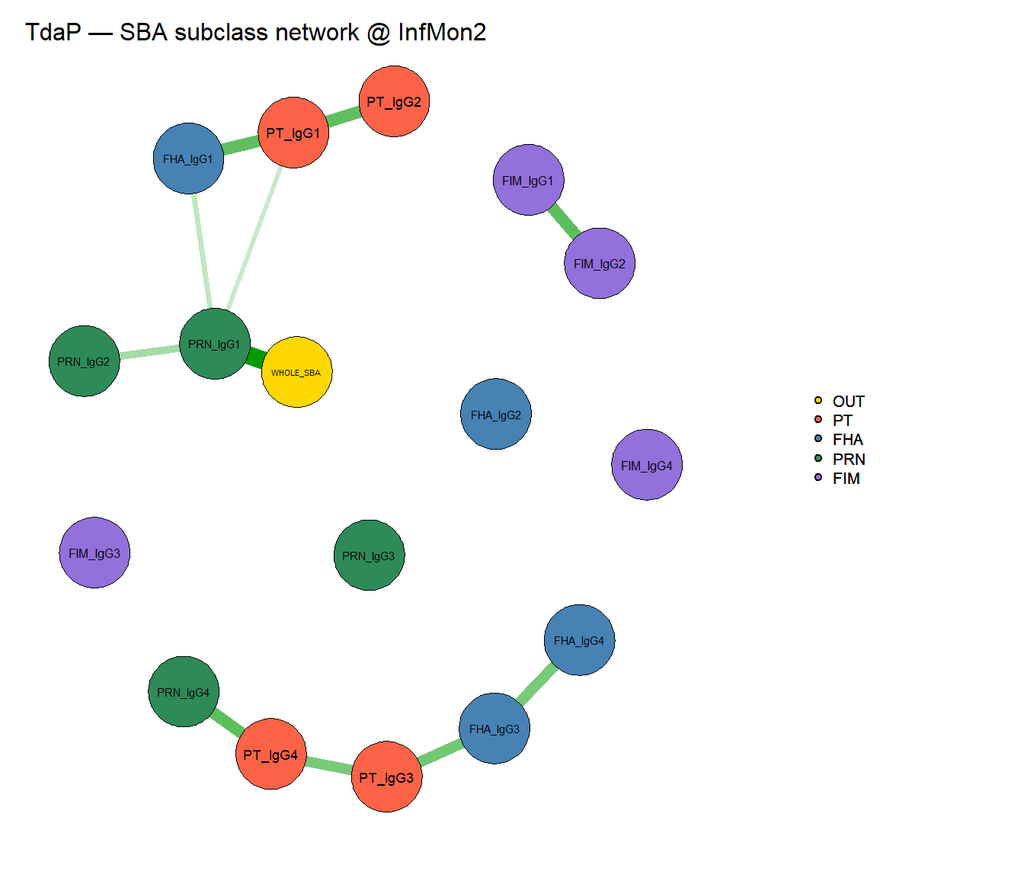

Bridge centrality — TdaP — SBA subclass network @ InfMon2

| Variable | Bridge_Strength | Bridge_EI |
| --- | --- | --- |
| PRN_IgG1 | 1.085 | 1.085 |
| WHOLE_SBA | 0.745 | 0.745 |
| FHA_IgG1 | 0.645 | 0.645 |
| PT_IgG1 | 0.623 | 0.623 |
| PT_IgG4 | 0.478 | 0.478 |
| PRN_IgG4 | 0.478 | 0.478 |
| PT_IgG3 | 0.411 | 0.411 |
| FHA_IgG3 | 0.411 | 0.411 |
| PT_IgG2 | 0.000 | 0.000 |
| FHA_IgG2 | 0.000 | 0.000 |
| FHA_IgG4 | 0.000 | 0.000 |
| PRN_IgG2 | 0.000 | 0.000 |
| PRN_IgG3 | 0.000 | 0.000 |
| FIM_IgG1 | 0.000 | 0.000 |
| FIM_IgG2 | 0.000 | 0.000 |
| FIM_IgG3 | 0.000 | 0.000 |
| FIM_IgG4 | 0.000 | 0.000 |

**TdaP — SBA FcγR+ADCD network @ InfMon2** (n = 102)

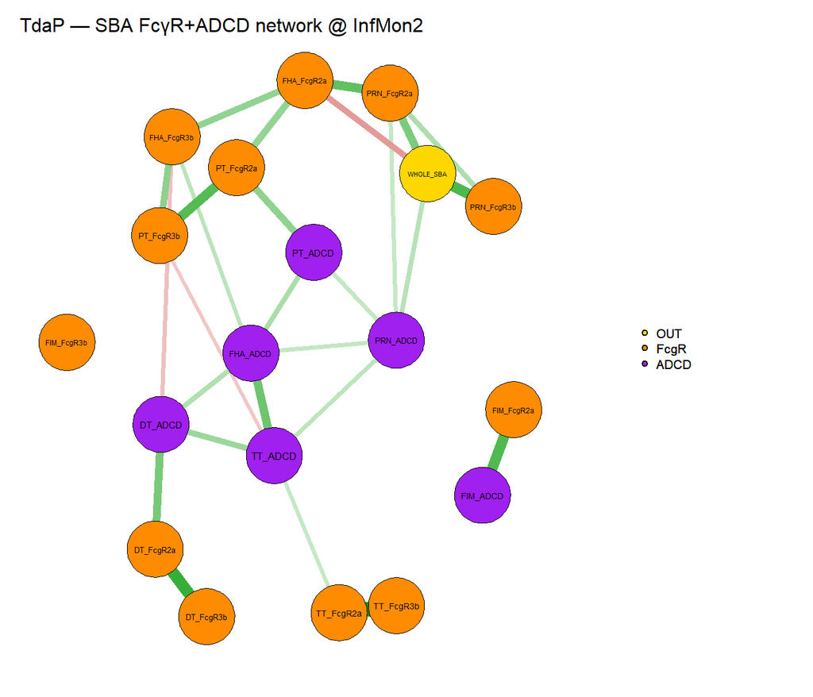

Bridge centrality — TdaP — SBA FcγR+ADCD network @ InfMon2

| Variable | Bridge_Strength | Bridge_EI |
| --- | --- | --- |
| WHOLE_SBA | 1.476 | 0.851 |
| DT_ADCD | 0.610 | 0.219 |
| PRN_FcgR2a | 0.581 | 0.581 |
| PRN_FcgR3b | 0.543 | 0.543 |
| FIM_FcgR2a | 0.537 | 0.537 |
| FIM_ADCD | 0.537 | 0.537 |
| DT_FcgR2a | 0.415 | 0.415 |
| FHA_FcgR3b | 0.404 | 0.013 |
| PRN_ADCD | 0.399 | 0.399 |
| TT_ADCD | 0.353 | 0.006 |
| PT_FcgR2a | 0.344 | 0.344 |
| PT_ADCD | 0.344 | 0.344 |
| FHA_FcgR2a | 0.313 | -0.313 |
| FHA_ADCD | 0.209 | 0.209 |
| TT_FcgR2a | 0.179 | 0.179 |
| PT_FcgR3b | 0.174 | -0.174 |
| DT_FcgR3b | 0.000 | 0.000 |
| TT_FcgR3b | 0.000 | 0.000 |
| FIM_FcgR3b | 0.000 | 0.000 |

**TT — SBA subclass network @ InfMon2** (n = 117)

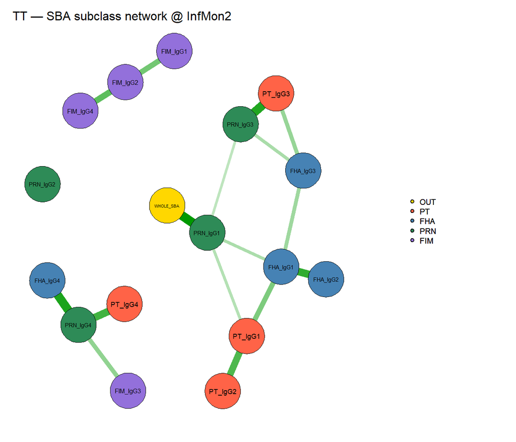

Bridge centrality — TT — SBA subclass network @ InfMon2

| Variable | Bridge_Strength | Bridge_EI |
| --- | --- | --- |
| PRN_IgG4 | 1.330 | 1.330 |
| PRN_IgG1 | 1.044 | 1.044 |
| PT_IgG3 | 0.822 | 0.822 |
| PRN_IgG3 | 0.777 | 0.777 |
| WHOLE_SBA | 0.643 | 0.643 |
| FHA_IgG4 | 0.573 | 0.573 |
| FHA_IgG1 | 0.541 | 0.541 |
| PT_IgG1 | 0.517 | 0.517 |
| FHA_IgG3 | 0.480 | 0.480 |
| PT_IgG4 | 0.478 | 0.478 |
| FIM_IgG3 | 0.278 | 0.278 |
| PT_IgG2 | 0.000 | 0.000 |
| FHA_IgG2 | 0.000 | 0.000 |
| PRN_IgG2 | 0.000 | 0.000 |
| FIM_IgG1 | 0.000 | 0.000 |
| FIM_IgG2 | 0.000 | 0.000 |
| FIM_IgG4 | 0.000 | 0.000 |

**TT — SBA FcγR+ADCD network @ InfMon2** (n = 117)

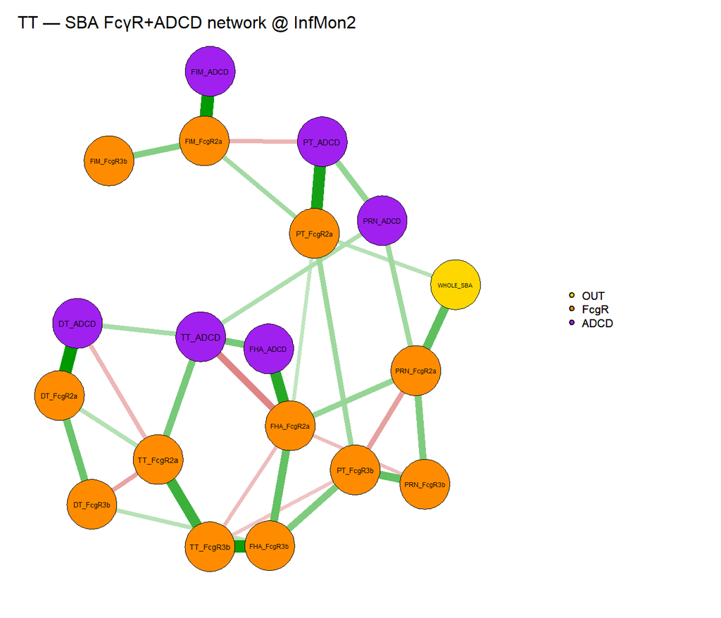

Bridge centrality — TT — SBA FcγR+ADCD network @ InfMon2

| Variable | Bridge_Strength | Bridge_EI |
| --- | --- | --- |
| FHA_FcgR2a | 0.901 | 0.248 |
| FIM_FcgR2a | 0.875 | 0.470 |
| DT_ADCD | 0.871 | 0.487 |
| PT_ADCD | 0.825 | 0.420 |
| PT_FcgR2a | 0.819 | 0.819 |
| TT_ADCD | 0.686 | 0.032 |
| PRN_FcgR2a | 0.683 | 0.683 |
| DT_FcgR2a | 0.679 | 0.679 |
| FIM_ADCD | 0.673 | 0.673 |
| WHOLE_SBA | 0.623 | 0.623 |
| FHA_ADCD | 0.575 | 0.575 |
| TT_FcgR2a | 0.551 | 0.168 |
| PRN_ADCD | 0.256 | 0.256 |
| PT_FcgR3b | 0.000 | 0.000 |
| FHA_FcgR3b | 0.000 | 0.000 |
| PRN_FcgR3b | 0.000 | 0.000 |
| DT_FcgR3b | 0.000 | 0.000 |
| TT_FcgR3b | 0.000 | 0.000 |
| FIM_FcgR3b | 0.000 | 0.000 |

```r
.mark("stage4_networks")
```

## STAGE 5 — Network Comparison Tests (NCT)

> **🧭 Maps to interpretation:** NCT at the single 8-week visit: maternal arm (TdaP vs TT) and infant arm (aP vs wP) within maternal arm. Temporal contrasts are not applicable at a single visit.
> - §7 (cross-arm network comparison)

```r
.stage(5, N_STAGES, sprintf("NCT permutations (it = %d)", NCT_IT))
nct_subset <- function(dat, nodes) dat %>%
  dplyr::select(dplyr::all_of(nodes)) %>% tidyr::drop_na()
run_nct <- function(d1, d2, lab) {
  cat(sprintf("\n**%s** — n1 = %d, n2 = %d\n\n", lab, nrow(d1), nrow(d2)))
  .info("NCT %-48s n1=%d n2=%d", lab, nrow(d1), nrow(d2))
  if (nrow(d1) < NETWORK_MIN || nrow(d2) < NETWORK_MIN) {
    cat(sprintf("*One or both groups n < %d; NCT skipped.*\n\n", NETWORK_MIN)); return(invisible()) }
  res <- tryCatch(NetworkComparisonTest::NCT(d1, d2, it = NCT_IT, test.edges = FALSE,
                  test.centrality = TRUE, centrality = c("strength", "expectedInfluence")),
                  error = function(e) NULL)
  if (is.null(res)) { cat("*NCT failed.*\n\n"); return(invisible()) }
  cat(sprintf("- Network-structure invariance (M) p = %.3f\n", res$nwinv.pval))
  cat(sprintf("- Global-strength invariance (S) p = %.3f\n\n", res$glstrinv.pval))
}
if (RUN_NCT) {
  nodes <- NET_SUBCLASS_NODES
  for (md in DATA_MODES) {
    cat("### Mode: `", md, "`\n\n", sep = "")
    sx <- strata_by_mode[[md]]
    run_nct(nct_subset(sx[["TdaP"]]$data, nodes), nct_subset(sx[["TT"]]$data, nodes),
            sprintf("Maternal arm: TdaP vs TT @ %s", CONC_VISIT))
    for (m in cfg$maternal_arms) {
      ka <- paste0(m, "_aP"); kw <- paste0(m, "_wP")
      if (!is.null(sx[[ka]]) && !is.null(sx[[kw]]))
        run_nct(nct_subset(sx[[ka]]$data, nodes), nct_subset(sx[[kw]]$data, nodes),
                sprintf("Infant arm within %s: aP vs wP @ %s", m, CONC_VISIT))
    }
  }
} else cat("*NCT disabled (RUN_NCT = FALSE or packages absent).*\n\n")
```

### Mode: `raw`

**Maternal arm: TdaP vs TT @ InfMon2** — n1 = 104, n2 = 117

[output not shown]

**Infant arm within TdaP: aP vs wP @ InfMon2** — n1 = 50, n2 = 54

[output not shown]

**Infant arm within TT: aP vs wP @ InfMon2** — n1 = 62, n2 = 55

[output not shown]

```r
.mark("stage5_nct")
```

## Run Manifest and Participant Accounting

```r
message(sprintf("[%s | +%5.1fs] concurrent v2 DONE — endpoint=%s", .hms(), .el(), cfg$endpoint))
tm <- dplyr::bind_rows(.RUNLOG$rows)
if (nrow(tm)) {
  tm$stage_seconds <- round(c(tm$elapsed_s[1], diff(tm$elapsed_s)), 1)
  knitr::kable(tm, caption = "Stage timing (cumulative and per-stage seconds).",
               col.names = c("Step", "Cumulative (s)", "This stage (s)")) %>% print()
  cat("\n")
}
```

Stage timing (cumulative and per-stage seconds).

| Step | Cumulative (s) | This stage (s) |
| --- | --- | --- |
| stage1_prep | 1.0 | 1.0 |
| stage2_regression | 13.6 | 12.6 |
| stage3_lmer | 14.8 | 1.2 |
| stage4_networks | 22.1 | 7.3 |
| stage5_nct | 522.9 | 500.8 |

```r
nt_render(nt, part = "Concurrent",
          caption = "Participant accounting for every concurrent model / network (both modes).")
```

Participant accounting for every concurrent model / network (both modes).

| Section | Stratum | Model | N entered | N used | N dropped | Dropped due to (NA driver) |
| --- | --- | --- | --- | --- | --- | --- |
| Antigen · raw | TdaP — all infant arms | Antigen totals (6) [raw] | 141 | 105 | 36 | WHOLE_SBA (36 NA) |
| Subclass · raw | TdaP — all infant arms | PT subclasses [raw] | 141 | 104 | 37 | WHOLE_SBA (36 NA); PT_IgG1 (11 NA); PT_IgG2 (11 NA); PT_IgG3 (11 NA); PT_IgG4 (11 NA) |
| Subclass · raw | TdaP — all infant arms | FHA subclasses [raw] | 141 | 104 | 37 | WHOLE_SBA (36 NA); FHA_IgG1 (11 NA); FHA_IgG2 (11 NA); FHA_IgG3 (11 NA); FHA_IgG4 (11 NA) |
| Subclass · raw | TdaP — all infant arms | PRN subclasses [raw] | 141 | 104 | 37 | WHOLE_SBA (36 NA); PRN_IgG1 (11 NA); PRN_IgG2 (11 NA); PRN_IgG3 (11 NA); PRN_IgG4 (11 NA) |
| Subclass · raw | TdaP — all infant arms | FIM subclasses [raw] | 141 | 104 | 37 | WHOLE_SBA (36 NA); FIM_IgG1 (11 NA); FIM_IgG2 (11 NA); FIM_IgG3 (11 NA); FIM_IgG4 (11 NA) |
| FcgR · raw | TdaP — all infant arms | FcγR binding (all antigens) [raw] | 141 | 104 | 37 | WHOLE_SBA (36 NA); PT_FcgR2a (11 NA); PT_FcgR3b (11 NA); FHA_FcgR2a (11 NA); FHA_FcgR3b (11 NA); PRN_FcgR2a (11 NA); PRN_FcgR3b (11 NA); DT_FcgR2a (11 NA); DT_FcgR3b (11 NA); TT_FcgR2a (11 NA); TT_Fcg… |
| Effector · raw | TdaP — all infant arms | ADCD (all antigens) [raw] | 141 | 102 | 39 | WHOLE_SBA (36 NA); PT_ADCD (13 NA); FHA_ADCD (13 NA); PRN_ADCD (13 NA); DT_ADCD (13 NA); TT_ADCD (13 NA); FIM_ADCD (13 NA) |
| Effector · raw | TdaP — all infant arms | ADCP + ADNP (PT/PRN/DT/TT) [raw] | 141 | 100 | 41 | WHOLE_SBA (36 NA); PT_ADCP (15 NA); PT_ADNP (15 NA); PRN_ADCP (15 NA); PRN_ADNP (15 NA); DT_ADCP (15 NA); DT_ADNP (15 NA); TT_ADCP (15 NA); TT_ADNP (15 NA) |
| Full · raw | TdaP — all infant arms | Full subclass (PT/FHA/PRN/DT/TT ×4) [raw] | 141 | 104 | 37 | WHOLE_SBA (36 NA); PT_IgG1 (11 NA); PT_IgG2 (11 NA); PT_IgG3 (11 NA); PT_IgG4 (11 NA); FHA_IgG1 (11 NA); FHA_IgG2 (11 NA); FHA_IgG3 (11 NA); FHA_IgG4 (11 NA); PRN_IgG1 (11 NA); PRN_IgG2 (11 NA); PRN_I… |
| Ratio · raw | TdaP — all infant arms | Pro/tolerogenic ratios [raw] | 141 | 104 | 37 | WHOLE_SBA (36 NA); PT_ratio (11 NA); FHA_ratio (11 NA); PRN_ratio (11 NA) |
| Antigen · raw | TdaP / aP infants | Antigen totals (6) [raw] | 67 | 51 | 16 | WHOLE_SBA (16 NA) |
| Subclass · raw | TdaP / aP infants | PT subclasses [raw] | 67 | 50 | 17 | WHOLE_SBA (16 NA); PT_IgG1 (9 NA); PT_IgG2 (9 NA); PT_IgG3 (9 NA); PT_IgG4 (9 NA) |
| Subclass · raw | TdaP / aP infants | FHA subclasses [raw] | 67 | 50 | 17 | WHOLE_SBA (16 NA); FHA_IgG1 (9 NA); FHA_IgG2 (9 NA); FHA_IgG3 (9 NA); FHA_IgG4 (9 NA) |
| Subclass · raw | TdaP / aP infants | PRN subclasses [raw] | 67 | 50 | 17 | WHOLE_SBA (16 NA); PRN_IgG1 (9 NA); PRN_IgG2 (9 NA); PRN_IgG3 (9 NA); PRN_IgG4 (9 NA) |
| Subclass · raw | TdaP / aP infants | FIM subclasses [raw] | 67 | 50 | 17 | WHOLE_SBA (16 NA); FIM_IgG1 (9 NA); FIM_IgG2 (9 NA); FIM_IgG3 (9 NA); FIM_IgG4 (9 NA) |
| FcgR · raw | TdaP / aP infants | FcγR binding (all antigens) [raw] | 67 | 50 | 17 | WHOLE_SBA (16 NA); PT_FcgR2a (9 NA); PT_FcgR3b (9 NA); FHA_FcgR2a (9 NA); FHA_FcgR3b (9 NA); PRN_FcgR2a (9 NA); PRN_FcgR3b (9 NA); DT_FcgR2a (9 NA); DT_FcgR3b (9 NA); TT_FcgR2a (9 NA); TT_FcgR3b (9 NA… |
| Effector · raw | TdaP / aP infants | ADCD (all antigens) [raw] | 67 | 50 | 17 | WHOLE_SBA (16 NA); PT_ADCD (9 NA); FHA_ADCD (9 NA); PRN_ADCD (9 NA); DT_ADCD (9 NA); TT_ADCD (9 NA); FIM_ADCD (9 NA) |
| Effector · raw | TdaP / aP infants | ADCP + ADNP (PT/PRN/DT/TT) [raw] | 67 | 50 | 17 | WHOLE_SBA (16 NA); PT_ADCP (9 NA); PT_ADNP (9 NA); PRN_ADCP (9 NA); PRN_ADNP (9 NA); DT_ADCP (9 NA); DT_ADNP (9 NA); TT_ADCP (9 NA); TT_ADNP (9 NA) |
| Full · raw | TdaP / aP infants | Full subclass (PT/FHA/PRN/DT/TT ×4) [raw] | 67 | 50 | 17 | WHOLE_SBA (16 NA); PT_IgG1 (9 NA); PT_IgG2 (9 NA); PT_IgG3 (9 NA); PT_IgG4 (9 NA); FHA_IgG1 (9 NA); FHA_IgG2 (9 NA); FHA_IgG3 (9 NA); FHA_IgG4 (9 NA); PRN_IgG1 (9 NA); PRN_IgG2 (9 NA); PRN_IgG3 (9 NA)… |
| Ratio · raw | TdaP / aP infants | Pro/tolerogenic ratios [raw] | 67 | 50 | 17 | WHOLE_SBA (16 NA); PT_ratio (9 NA); FHA_ratio (9 NA); PRN_ratio (9 NA) |
| Antigen · raw | TdaP / wP infants | Antigen totals (6) [raw] | 74 | 54 | 20 | WHOLE_SBA (20 NA) |
| Subclass · raw | TdaP / wP infants | PT subclasses [raw] | 74 | 54 | 20 | WHOLE_SBA (20 NA); PT_IgG1 (2 NA); PT_IgG2 (2 NA); PT_IgG3 (2 NA); PT_IgG4 (2 NA) |
| Subclass · raw | TdaP / wP infants | FHA subclasses [raw] | 74 | 54 | 20 | WHOLE_SBA (20 NA); FHA_IgG1 (2 NA); FHA_IgG2 (2 NA); FHA_IgG3 (2 NA); FHA_IgG4 (2 NA) |
| Subclass · raw | TdaP / wP infants | PRN subclasses [raw] | 74 | 54 | 20 | WHOLE_SBA (20 NA); PRN_IgG1 (2 NA); PRN_IgG2 (2 NA); PRN_IgG3 (2 NA); PRN_IgG4 (2 NA) |
| Subclass · raw | TdaP / wP infants | FIM subclasses [raw] | 74 | 54 | 20 | WHOLE_SBA (20 NA); FIM_IgG1 (2 NA); FIM_IgG2 (2 NA); FIM_IgG3 (2 NA); FIM_IgG4 (2 NA) |
| FcgR · raw | TdaP / wP infants | FcγR binding (all antigens) [raw] | 74 | 54 | 20 | WHOLE_SBA (20 NA); PT_FcgR2a (2 NA); PT_FcgR3b (2 NA); FHA_FcgR2a (2 NA); FHA_FcgR3b (2 NA); PRN_FcgR2a (2 NA); PRN_FcgR3b (2 NA); DT_FcgR2a (2 NA); DT_FcgR3b (2 NA); TT_FcgR2a (2 NA); TT_FcgR3b (2 NA… |
| Effector · raw | TdaP / wP infants | ADCD (all antigens) [raw] | 74 | 52 | 22 | WHOLE_SBA (20 NA); PT_ADCD (4 NA); FHA_ADCD (4 NA); PRN_ADCD (4 NA); DT_ADCD (4 NA); TT_ADCD (4 NA); FIM_ADCD (4 NA) |
| Effector · raw | TdaP / wP infants | ADCP + ADNP (PT/PRN/DT/TT) [raw] | 74 | 50 | 24 | WHOLE_SBA (20 NA); PT_ADCP (6 NA); PT_ADNP (6 NA); PRN_ADCP (6 NA); PRN_ADNP (6 NA); DT_ADCP (6 NA); DT_ADNP (6 NA); TT_ADCP (6 NA); TT_ADNP (6 NA) |
| Full · raw | TdaP / wP infants | Full subclass (PT/FHA/PRN/DT/TT ×4) [raw] | 74 | 54 | 20 | WHOLE_SBA (20 NA); PT_IgG1 (2 NA); PT_IgG2 (2 NA); PT_IgG3 (2 NA); PT_IgG4 (2 NA); FHA_IgG1 (2 NA); FHA_IgG2 (2 NA); FHA_IgG3 (2 NA); FHA_IgG4 (2 NA); PRN_IgG1 (2 NA); PRN_IgG2 (2 NA); PRN_IgG3 (2 NA)… |
| Ratio · raw | TdaP / wP infants | Pro/tolerogenic ratios [raw] | 74 | 54 | 20 | WHOLE_SBA (20 NA); PT_ratio (2 NA); FHA_ratio (2 NA); PRN_ratio (2 NA) |
| Antigen · raw | TT — all infant arms | Antigen totals (6) [raw] | 146 | 117 | 29 | WHOLE_SBA (29 NA) |
| Subclass · raw | TT — all infant arms | PT subclasses [raw] | 146 | 117 | 29 | WHOLE_SBA (29 NA); PT_IgG1 (12 NA); PT_IgG2 (12 NA); PT_IgG3 (12 NA); PT_IgG4 (12 NA) |
| Subclass · raw | TT — all infant arms | FHA subclasses [raw] | 146 | 117 | 29 | WHOLE_SBA (29 NA); FHA_IgG1 (12 NA); FHA_IgG2 (12 NA); FHA_IgG3 (12 NA); FHA_IgG4 (12 NA) |
| Subclass · raw | TT — all infant arms | PRN subclasses [raw] | 146 | 117 | 29 | WHOLE_SBA (29 NA); PRN_IgG1 (12 NA); PRN_IgG2 (12 NA); PRN_IgG3 (12 NA); PRN_IgG4 (12 NA) |
| Subclass · raw | TT — all infant arms | FIM subclasses [raw] | 146 | 117 | 29 | WHOLE_SBA (29 NA); FIM_IgG1 (12 NA); FIM_IgG2 (12 NA); FIM_IgG3 (12 NA); FIM_IgG4 (12 NA) |
| FcgR · raw | TT — all infant arms | FcγR binding (all antigens) [raw] | 146 | 117 | 29 | WHOLE_SBA (29 NA); PT_FcgR2a (12 NA); PT_FcgR3b (12 NA); FHA_FcgR2a (12 NA); FHA_FcgR3b (12 NA); PRN_FcgR2a (12 NA); PRN_FcgR3b (12 NA); DT_FcgR2a (12 NA); DT_FcgR3b (12 NA); TT_FcgR2a (12 NA); TT_Fcg… |
| Effector · raw | TT — all infant arms | ADCD (all antigens) [raw] | 146 | 117 | 29 | WHOLE_SBA (29 NA); PT_ADCD (12 NA); FHA_ADCD (12 NA); PRN_ADCD (12 NA); DT_ADCD (12 NA); TT_ADCD (12 NA); FIM_ADCD (12 NA) |
| Effector · raw | TT — all infant arms | ADCP + ADNP (PT/PRN/DT/TT) [raw] | 146 | 110 | 36 | WHOLE_SBA (29 NA); PT_ADCP (19 NA); PT_ADNP (19 NA); PRN_ADCP (19 NA); PRN_ADNP (19 NA); DT_ADCP (19 NA); DT_ADNP (19 NA); TT_ADCP (19 NA); TT_ADNP (19 NA) |
| Full · raw | TT — all infant arms | Full subclass (PT/FHA/PRN/DT/TT ×4) [raw] | 146 | 117 | 29 | WHOLE_SBA (29 NA); PT_IgG1 (12 NA); PT_IgG2 (12 NA); PT_IgG3 (12 NA); PT_IgG4 (12 NA); FHA_IgG1 (12 NA); FHA_IgG2 (12 NA); FHA_IgG3 (12 NA); FHA_IgG4 (12 NA); PRN_IgG1 (12 NA); PRN_IgG2 (12 NA); PRN_I… |
| Ratio · raw | TT — all infant arms | Pro/tolerogenic ratios [raw] | 146 | 117 | 29 | WHOLE_SBA (29 NA); PT_ratio (12 NA); FHA_ratio (12 NA); PRN_ratio (12 NA) |
| Antigen · raw | TT / aP infants | Antigen totals (6) [raw] | 79 | 62 | 17 | WHOLE_SBA (17 NA) |
| Subclass · raw | TT / aP infants | PT subclasses [raw] | 79 | 62 | 17 | WHOLE_SBA (17 NA); PT_IgG1 (10 NA); PT_IgG2 (10 NA); PT_IgG3 (10 NA); PT_IgG4 (10 NA) |
| Subclass · raw | TT / aP infants | FHA subclasses [raw] | 79 | 62 | 17 | WHOLE_SBA (17 NA); FHA_IgG1 (10 NA); FHA_IgG2 (10 NA); FHA_IgG3 (10 NA); FHA_IgG4 (10 NA) |
| Subclass · raw | TT / aP infants | PRN subclasses [raw] | 79 | 62 | 17 | WHOLE_SBA (17 NA); PRN_IgG1 (10 NA); PRN_IgG2 (10 NA); PRN_IgG3 (10 NA); PRN_IgG4 (10 NA) |
| Subclass · raw | TT / aP infants | FIM subclasses [raw] | 79 | 62 | 17 | WHOLE_SBA (17 NA); FIM_IgG1 (10 NA); FIM_IgG2 (10 NA); FIM_IgG3 (10 NA); FIM_IgG4 (10 NA) |
| FcgR · raw | TT / aP infants | FcγR binding (all antigens) [raw] | 79 | 62 | 17 | WHOLE_SBA (17 NA); PT_FcgR2a (10 NA); PT_FcgR3b (10 NA); FHA_FcgR2a (10 NA); FHA_FcgR3b (10 NA); PRN_FcgR2a (10 NA); PRN_FcgR3b (10 NA); DT_FcgR2a (10 NA); DT_FcgR3b (10 NA); TT_FcgR2a (10 NA); TT_Fcg… |
| Effector · raw | TT / aP infants | ADCD (all antigens) [raw] | 79 | 62 | 17 | WHOLE_SBA (17 NA); PT_ADCD (10 NA); FHA_ADCD (10 NA); PRN_ADCD (10 NA); DT_ADCD (10 NA); TT_ADCD (10 NA); FIM_ADCD (10 NA) |
| Effector · raw | TT / aP infants | ADCP + ADNP (PT/PRN/DT/TT) [raw] | 79 | 59 | 20 | WHOLE_SBA (17 NA); PT_ADCP (13 NA); PT_ADNP (13 NA); PRN_ADCP (13 NA); PRN_ADNP (13 NA); DT_ADCP (13 NA); DT_ADNP (13 NA); TT_ADCP (13 NA); TT_ADNP (13 NA) |
| Full · raw | TT / aP infants | Full subclass (PT/FHA/PRN/DT/TT ×4) [raw] | 79 | 62 | 17 | WHOLE_SBA (17 NA); PT_IgG1 (10 NA); PT_IgG2 (10 NA); PT_IgG3 (10 NA); PT_IgG4 (10 NA); FHA_IgG1 (10 NA); FHA_IgG2 (10 NA); FHA_IgG3 (10 NA); FHA_IgG4 (10 NA); PRN_IgG1 (10 NA); PRN_IgG2 (10 NA); PRN_I… |
| Ratio · raw | TT / aP infants | Pro/tolerogenic ratios [raw] | 79 | 62 | 17 | WHOLE_SBA (17 NA); PT_ratio (10 NA); FHA_ratio (10 NA); PRN_ratio (10 NA) |
| Antigen · raw | TT / wP infants | Antigen totals (6) [raw] | 67 | 55 | 12 | WHOLE_SBA (12 NA) |
| Subclass · raw | TT / wP infants | PT subclasses [raw] | 67 | 55 | 12 | WHOLE_SBA (12 NA); PT_IgG1 (2 NA); PT_IgG2 (2 NA); PT_IgG3 (2 NA); PT_IgG4 (2 NA) |
| Subclass · raw | TT / wP infants | FHA subclasses [raw] | 67 | 55 | 12 | WHOLE_SBA (12 NA); FHA_IgG1 (2 NA); FHA_IgG2 (2 NA); FHA_IgG3 (2 NA); FHA_IgG4 (2 NA) |
| Subclass · raw | TT / wP infants | PRN subclasses [raw] | 67 | 55 | 12 | WHOLE_SBA (12 NA); PRN_IgG1 (2 NA); PRN_IgG2 (2 NA); PRN_IgG3 (2 NA); PRN_IgG4 (2 NA) |
| Subclass · raw | TT / wP infants | FIM subclasses [raw] | 67 | 55 | 12 | WHOLE_SBA (12 NA); FIM_IgG1 (2 NA); FIM_IgG2 (2 NA); FIM_IgG3 (2 NA); FIM_IgG4 (2 NA) |
| FcgR · raw | TT / wP infants | FcγR binding (all antigens) [raw] | 67 | 55 | 12 | WHOLE_SBA (12 NA); PT_FcgR2a (2 NA); PT_FcgR3b (2 NA); FHA_FcgR2a (2 NA); FHA_FcgR3b (2 NA); PRN_FcgR2a (2 NA); PRN_FcgR3b (2 NA); DT_FcgR2a (2 NA); DT_FcgR3b (2 NA); TT_FcgR2a (2 NA); TT_FcgR3b (2 NA… |
| Effector · raw | TT / wP infants | ADCD (all antigens) [raw] | 67 | 55 | 12 | WHOLE_SBA (12 NA); PT_ADCD (2 NA); FHA_ADCD (2 NA); PRN_ADCD (2 NA); DT_ADCD (2 NA); TT_ADCD (2 NA); FIM_ADCD (2 NA) |
| Effector · raw | TT / wP infants | ADCP + ADNP (PT/PRN/DT/TT) [raw] | 67 | 51 | 16 | WHOLE_SBA (12 NA); PT_ADCP (6 NA); PT_ADNP (6 NA); PRN_ADCP (6 NA); PRN_ADNP (6 NA); DT_ADCP (6 NA); DT_ADNP (6 NA); TT_ADCP (6 NA); TT_ADNP (6 NA) |
| Full · raw | TT / wP infants | Full subclass (PT/FHA/PRN/DT/TT ×4) [raw] | 67 | 55 | 12 | WHOLE_SBA (12 NA); PT_IgG1 (2 NA); PT_IgG2 (2 NA); PT_IgG3 (2 NA); PT_IgG4 (2 NA); FHA_IgG1 (2 NA); FHA_IgG2 (2 NA); FHA_IgG3 (2 NA); FHA_IgG4 (2 NA); PRN_IgG1 (2 NA); PRN_IgG2 (2 NA); PRN_IgG3 (2 NA)… |
| Ratio · raw | TT / wP infants | Pro/tolerogenic ratios [raw] | 67 | 55 | 12 | WHOLE_SBA (12 NA); PT_ratio (2 NA); FHA_ratio (2 NA); PRN_ratio (2 NA) |
| subclass network @ InfMon2 | TdaP — SBA subclass network @ InfMon2 | TdaP | 141 | 104 | 37 | WHOLE_SBA (36 NA); PT_IgG1 (11 NA); PT_IgG2 (11 NA); PT_IgG3 (11 NA); PT_IgG4 (11 NA); FHA_IgG1 (11 NA); FHA_IgG2 (11 NA); FHA_IgG3 (11 NA); FHA_IgG4 (11 NA); PRN_IgG1 (11 NA); PRN_IgG2 (11 NA); PRN_I… |
| effector network @ InfMon2 | TdaP — SBA FcγR+ADCD network @ InfMon2 | TdaP | 141 | 102 | 39 | WHOLE_SBA (36 NA); PT_ADCD (13 NA); FHA_ADCD (13 NA); PRN_ADCD (13 NA); DT_ADCD (13 NA); TT_ADCD (13 NA); FIM_ADCD (13 NA); PT_FcgR2a (11 NA); PT_FcgR3b (11 NA); FHA_FcgR2a (11 NA); FHA_FcgR3b (11 NA)… |
| subclass network @ InfMon2 | TT — SBA subclass network @ InfMon2 | TT | 146 | 117 | 29 | WHOLE_SBA (29 NA); PT_IgG1 (12 NA); PT_IgG2 (12 NA); PT_IgG3 (12 NA); PT_IgG4 (12 NA); FHA_IgG1 (12 NA); FHA_IgG2 (12 NA); FHA_IgG3 (12 NA); FHA_IgG4 (12 NA); PRN_IgG1 (12 NA); PRN_IgG2 (12 NA); PRN_I… |
| effector network @ InfMon2 | TT — SBA FcγR+ADCD network @ InfMon2 | TT | 146 | 117 | 29 | WHOLE_SBA (29 NA); PT_FcgR2a (12 NA); PT_FcgR3b (12 NA); FHA_FcgR2a (12 NA); FHA_FcgR3b (12 NA); PRN_FcgR2a (12 NA); PRN_FcgR3b (12 NA); DT_FcgR2a (12 NA); DT_FcgR3b (12 NA); TT_FcgR2a (12 NA); TT_Fcg… |

# Synthesis Questions to Address (Concurrent)

# Participant Accounting (Concurrent)

A single attrition ledger for every concurrent model and network fitted in this document, so differing sample sizes between sections are fully traceable. (This mirrors the concurrent slice of the full pipeline’s global ledger.)

```r
nt_render(nt, caption = "Participant accounting across all concurrent models / networks.")
```

Participant accounting across all concurrent models / networks.

| Section | Stratum | Model | N entered | N used | N dropped | Dropped due to (NA driver) |
| --- | --- | --- | --- | --- | --- | --- |
| Antigen · raw | TdaP — all infant arms | Antigen totals (6) [raw] | 141 | 105 | 36 | WHOLE_SBA (36 NA) |
| Subclass · raw | TdaP — all infant arms | PT subclasses [raw] | 141 | 104 | 37 | WHOLE_SBA (36 NA); PT_IgG1 (11 NA); PT_IgG2 (11 NA); PT_IgG3 (11 NA); PT_IgG4 (11 NA) |
| Subclass · raw | TdaP — all infant arms | FHA subclasses [raw] | 141 | 104 | 37 | WHOLE_SBA (36 NA); FHA_IgG1 (11 NA); FHA_IgG2 (11 NA); FHA_IgG3 (11 NA); FHA_IgG4 (11 NA) |
| Subclass · raw | TdaP — all infant arms | PRN subclasses [raw] | 141 | 104 | 37 | WHOLE_SBA (36 NA); PRN_IgG1 (11 NA); PRN_IgG2 (11 NA); PRN_IgG3 (11 NA); PRN_IgG4 (11 NA) |
| Subclass · raw | TdaP — all infant arms | FIM subclasses [raw] | 141 | 104 | 37 | WHOLE_SBA (36 NA); FIM_IgG1 (11 NA); FIM_IgG2 (11 NA); FIM_IgG3 (11 NA); FIM_IgG4 (11 NA) |
| FcgR · raw | TdaP — all infant arms | FcγR binding (all antigens) [raw] | 141 | 104 | 37 | WHOLE_SBA (36 NA); PT_FcgR2a (11 NA); PT_FcgR3b (11 NA); FHA_FcgR2a (11 NA); FHA_FcgR3b (11 NA); PRN_FcgR2a (11 NA); PRN_FcgR3b (11 NA); DT_FcgR2a (11 NA); DT_FcgR3b (11 NA); TT_FcgR2a (11 NA); TT_Fcg… |
| Effector · raw | TdaP — all infant arms | ADCD (all antigens) [raw] | 141 | 102 | 39 | WHOLE_SBA (36 NA); PT_ADCD (13 NA); FHA_ADCD (13 NA); PRN_ADCD (13 NA); DT_ADCD (13 NA); TT_ADCD (13 NA); FIM_ADCD (13 NA) |
| Effector · raw | TdaP — all infant arms | ADCP + ADNP (PT/PRN/DT/TT) [raw] | 141 | 100 | 41 | WHOLE_SBA (36 NA); PT_ADCP (15 NA); PT_ADNP (15 NA); PRN_ADCP (15 NA); PRN_ADNP (15 NA); DT_ADCP (15 NA); DT_ADNP (15 NA); TT_ADCP (15 NA); TT_ADNP (15 NA) |
| Full · raw | TdaP — all infant arms | Full subclass (PT/FHA/PRN/DT/TT ×4) [raw] | 141 | 104 | 37 | WHOLE_SBA (36 NA); PT_IgG1 (11 NA); PT_IgG2 (11 NA); PT_IgG3 (11 NA); PT_IgG4 (11 NA); FHA_IgG1 (11 NA); FHA_IgG2 (11 NA); FHA_IgG3 (11 NA); FHA_IgG4 (11 NA); PRN_IgG1 (11 NA); PRN_IgG2 (11 NA); PRN_I… |
| Ratio · raw | TdaP — all infant arms | Pro/tolerogenic ratios [raw] | 141 | 104 | 37 | WHOLE_SBA (36 NA); PT_ratio (11 NA); FHA_ratio (11 NA); PRN_ratio (11 NA) |
| Antigen · raw | TdaP / aP infants | Antigen totals (6) [raw] | 67 | 51 | 16 | WHOLE_SBA (16 NA) |
| Subclass · raw | TdaP / aP infants | PT subclasses [raw] | 67 | 50 | 17 | WHOLE_SBA (16 NA); PT_IgG1 (9 NA); PT_IgG2 (9 NA); PT_IgG3 (9 NA); PT_IgG4 (9 NA) |
| Subclass · raw | TdaP / aP infants | FHA subclasses [raw] | 67 | 50 | 17 | WHOLE_SBA (16 NA); FHA_IgG1 (9 NA); FHA_IgG2 (9 NA); FHA_IgG3 (9 NA); FHA_IgG4 (9 NA) |
| Subclass · raw | TdaP / aP infants | PRN subclasses [raw] | 67 | 50 | 17 | WHOLE_SBA (16 NA); PRN_IgG1 (9 NA); PRN_IgG2 (9 NA); PRN_IgG3 (9 NA); PRN_IgG4 (9 NA) |
| Subclass · raw | TdaP / aP infants | FIM subclasses [raw] | 67 | 50 | 17 | WHOLE_SBA (16 NA); FIM_IgG1 (9 NA); FIM_IgG2 (9 NA); FIM_IgG3 (9 NA); FIM_IgG4 (9 NA) |
| FcgR · raw | TdaP / aP infants | FcγR binding (all antigens) [raw] | 67 | 50 | 17 | WHOLE_SBA (16 NA); PT_FcgR2a (9 NA); PT_FcgR3b (9 NA); FHA_FcgR2a (9 NA); FHA_FcgR3b (9 NA); PRN_FcgR2a (9 NA); PRN_FcgR3b (9 NA); DT_FcgR2a (9 NA); DT_FcgR3b (9 NA); TT_FcgR2a (9 NA); TT_FcgR3b (9 NA… |
| Effector · raw | TdaP / aP infants | ADCD (all antigens) [raw] | 67 | 50 | 17 | WHOLE_SBA (16 NA); PT_ADCD (9 NA); FHA_ADCD (9 NA); PRN_ADCD (9 NA); DT_ADCD (9 NA); TT_ADCD (9 NA); FIM_ADCD (9 NA) |
| Effector · raw | TdaP / aP infants | ADCP + ADNP (PT/PRN/DT/TT) [raw] | 67 | 50 | 17 | WHOLE_SBA (16 NA); PT_ADCP (9 NA); PT_ADNP (9 NA); PRN_ADCP (9 NA); PRN_ADNP (9 NA); DT_ADCP (9 NA); DT_ADNP (9 NA); TT_ADCP (9 NA); TT_ADNP (9 NA) |
| Full · raw | TdaP / aP infants | Full subclass (PT/FHA/PRN/DT/TT ×4) [raw] | 67 | 50 | 17 | WHOLE_SBA (16 NA); PT_IgG1 (9 NA); PT_IgG2 (9 NA); PT_IgG3 (9 NA); PT_IgG4 (9 NA); FHA_IgG1 (9 NA); FHA_IgG2 (9 NA); FHA_IgG3 (9 NA); FHA_IgG4 (9 NA); PRN_IgG1 (9 NA); PRN_IgG2 (9 NA); PRN_IgG3 (9 NA)… |
| Ratio · raw | TdaP / aP infants | Pro/tolerogenic ratios [raw] | 67 | 50 | 17 | WHOLE_SBA (16 NA); PT_ratio (9 NA); FHA_ratio (9 NA); PRN_ratio (9 NA) |
| Antigen · raw | TdaP / wP infants | Antigen totals (6) [raw] | 74 | 54 | 20 | WHOLE_SBA (20 NA) |
| Subclass · raw | TdaP / wP infants | PT subclasses [raw] | 74 | 54 | 20 | WHOLE_SBA (20 NA); PT_IgG1 (2 NA); PT_IgG2 (2 NA); PT_IgG3 (2 NA); PT_IgG4 (2 NA) |
| Subclass · raw | TdaP / wP infants | FHA subclasses [raw] | 74 | 54 | 20 | WHOLE_SBA (20 NA); FHA_IgG1 (2 NA); FHA_IgG2 (2 NA); FHA_IgG3 (2 NA); FHA_IgG4 (2 NA) |
| Subclass · raw | TdaP / wP infants | PRN subclasses [raw] | 74 | 54 | 20 | WHOLE_SBA (20 NA); PRN_IgG1 (2 NA); PRN_IgG2 (2 NA); PRN_IgG3 (2 NA); PRN_IgG4 (2 NA) |
| Subclass · raw | TdaP / wP infants | FIM subclasses [raw] | 74 | 54 | 20 | WHOLE_SBA (20 NA); FIM_IgG1 (2 NA); FIM_IgG2 (2 NA); FIM_IgG3 (2 NA); FIM_IgG4 (2 NA) |
| FcgR · raw | TdaP / wP infants | FcγR binding (all antigens) [raw] | 74 | 54 | 20 | WHOLE_SBA (20 NA); PT_FcgR2a (2 NA); PT_FcgR3b (2 NA); FHA_FcgR2a (2 NA); FHA_FcgR3b (2 NA); PRN_FcgR2a (2 NA); PRN_FcgR3b (2 NA); DT_FcgR2a (2 NA); DT_FcgR3b (2 NA); TT_FcgR2a (2 NA); TT_FcgR3b (2 NA… |
| Effector · raw | TdaP / wP infants | ADCD (all antigens) [raw] | 74 | 52 | 22 | WHOLE_SBA (20 NA); PT_ADCD (4 NA); FHA_ADCD (4 NA); PRN_ADCD (4 NA); DT_ADCD (4 NA); TT_ADCD (4 NA); FIM_ADCD (4 NA) |
| Effector · raw | TdaP / wP infants | ADCP + ADNP (PT/PRN/DT/TT) [raw] | 74 | 50 | 24 | WHOLE_SBA (20 NA); PT_ADCP (6 NA); PT_ADNP (6 NA); PRN_ADCP (6 NA); PRN_ADNP (6 NA); DT_ADCP (6 NA); DT_ADNP (6 NA); TT_ADCP (6 NA); TT_ADNP (6 NA) |
| Full · raw | TdaP / wP infants | Full subclass (PT/FHA/PRN/DT/TT ×4) [raw] | 74 | 54 | 20 | WHOLE_SBA (20 NA); PT_IgG1 (2 NA); PT_IgG2 (2 NA); PT_IgG3 (2 NA); PT_IgG4 (2 NA); FHA_IgG1 (2 NA); FHA_IgG2 (2 NA); FHA_IgG3 (2 NA); FHA_IgG4 (2 NA); PRN_IgG1 (2 NA); PRN_IgG2 (2 NA); PRN_IgG3 (2 NA)… |
| Ratio · raw | TdaP / wP infants | Pro/tolerogenic ratios [raw] | 74 | 54 | 20 | WHOLE_SBA (20 NA); PT_ratio (2 NA); FHA_ratio (2 NA); PRN_ratio (2 NA) |
| Antigen · raw | TT — all infant arms | Antigen totals (6) [raw] | 146 | 117 | 29 | WHOLE_SBA (29 NA) |
| Subclass · raw | TT — all infant arms | PT subclasses [raw] | 146 | 117 | 29 | WHOLE_SBA (29 NA); PT_IgG1 (12 NA); PT_IgG2 (12 NA); PT_IgG3 (12 NA); PT_IgG4 (12 NA) |
| Subclass · raw | TT — all infant arms | FHA subclasses [raw] | 146 | 117 | 29 | WHOLE_SBA (29 NA); FHA_IgG1 (12 NA); FHA_IgG2 (12 NA); FHA_IgG3 (12 NA); FHA_IgG4 (12 NA) |
| Subclass · raw | TT — all infant arms | PRN subclasses [raw] | 146 | 117 | 29 | WHOLE_SBA (29 NA); PRN_IgG1 (12 NA); PRN_IgG2 (12 NA); PRN_IgG3 (12 NA); PRN_IgG4 (12 NA) |
| Subclass · raw | TT — all infant arms | FIM subclasses [raw] | 146 | 117 | 29 | WHOLE_SBA (29 NA); FIM_IgG1 (12 NA); FIM_IgG2 (12 NA); FIM_IgG3 (12 NA); FIM_IgG4 (12 NA) |
| FcgR · raw | TT — all infant arms | FcγR binding (all antigens) [raw] | 146 | 117 | 29 | WHOLE_SBA (29 NA); PT_FcgR2a (12 NA); PT_FcgR3b (12 NA); FHA_FcgR2a (12 NA); FHA_FcgR3b (12 NA); PRN_FcgR2a (12 NA); PRN_FcgR3b (12 NA); DT_FcgR2a (12 NA); DT_FcgR3b (12 NA); TT_FcgR2a (12 NA); TT_Fcg… |
| Effector · raw | TT — all infant arms | ADCD (all antigens) [raw] | 146 | 117 | 29 | WHOLE_SBA (29 NA); PT_ADCD (12 NA); FHA_ADCD (12 NA); PRN_ADCD (12 NA); DT_ADCD (12 NA); TT_ADCD (12 NA); FIM_ADCD (12 NA) |
| Effector · raw | TT — all infant arms | ADCP + ADNP (PT/PRN/DT/TT) [raw] | 146 | 110 | 36 | WHOLE_SBA (29 NA); PT_ADCP (19 NA); PT_ADNP (19 NA); PRN_ADCP (19 NA); PRN_ADNP (19 NA); DT_ADCP (19 NA); DT_ADNP (19 NA); TT_ADCP (19 NA); TT_ADNP (19 NA) |
| Full · raw | TT — all infant arms | Full subclass (PT/FHA/PRN/DT/TT ×4) [raw] | 146 | 117 | 29 | WHOLE_SBA (29 NA); PT_IgG1 (12 NA); PT_IgG2 (12 NA); PT_IgG3 (12 NA); PT_IgG4 (12 NA); FHA_IgG1 (12 NA); FHA_IgG2 (12 NA); FHA_IgG3 (12 NA); FHA_IgG4 (12 NA); PRN_IgG1 (12 NA); PRN_IgG2 (12 NA); PRN_I… |
| Ratio · raw | TT — all infant arms | Pro/tolerogenic ratios [raw] | 146 | 117 | 29 | WHOLE_SBA (29 NA); PT_ratio (12 NA); FHA_ratio (12 NA); PRN_ratio (12 NA) |
| Antigen · raw | TT / aP infants | Antigen totals (6) [raw] | 79 | 62 | 17 | WHOLE_SBA (17 NA) |
| Subclass · raw | TT / aP infants | PT subclasses [raw] | 79 | 62 | 17 | WHOLE_SBA (17 NA); PT_IgG1 (10 NA); PT_IgG2 (10 NA); PT_IgG3 (10 NA); PT_IgG4 (10 NA) |
| Subclass · raw | TT / aP infants | FHA subclasses [raw] | 79 | 62 | 17 | WHOLE_SBA (17 NA); FHA_IgG1 (10 NA); FHA_IgG2 (10 NA); FHA_IgG3 (10 NA); FHA_IgG4 (10 NA) |
| Subclass · raw | TT / aP infants | PRN subclasses [raw] | 79 | 62 | 17 | WHOLE_SBA (17 NA); PRN_IgG1 (10 NA); PRN_IgG2 (10 NA); PRN_IgG3 (10 NA); PRN_IgG4 (10 NA) |
| Subclass · raw | TT / aP infants | FIM subclasses [raw] | 79 | 62 | 17 | WHOLE_SBA (17 NA); FIM_IgG1 (10 NA); FIM_IgG2 (10 NA); FIM_IgG3 (10 NA); FIM_IgG4 (10 NA) |
| FcgR · raw | TT / aP infants | FcγR binding (all antigens) [raw] | 79 | 62 | 17 | WHOLE_SBA (17 NA); PT_FcgR2a (10 NA); PT_FcgR3b (10 NA); FHA_FcgR2a (10 NA); FHA_FcgR3b (10 NA); PRN_FcgR2a (10 NA); PRN_FcgR3b (10 NA); DT_FcgR2a (10 NA); DT_FcgR3b (10 NA); TT_FcgR2a (10 NA); TT_Fcg… |
| Effector · raw | TT / aP infants | ADCD (all antigens) [raw] | 79 | 62 | 17 | WHOLE_SBA (17 NA); PT_ADCD (10 NA); FHA_ADCD (10 NA); PRN_ADCD (10 NA); DT_ADCD (10 NA); TT_ADCD (10 NA); FIM_ADCD (10 NA) |
| Effector · raw | TT / aP infants | ADCP + ADNP (PT/PRN/DT/TT) [raw] | 79 | 59 | 20 | WHOLE_SBA (17 NA); PT_ADCP (13 NA); PT_ADNP (13 NA); PRN_ADCP (13 NA); PRN_ADNP (13 NA); DT_ADCP (13 NA); DT_ADNP (13 NA); TT_ADCP (13 NA); TT_ADNP (13 NA) |
| Full · raw | TT / aP infants | Full subclass (PT/FHA/PRN/DT/TT ×4) [raw] | 79 | 62 | 17 | WHOLE_SBA (17 NA); PT_IgG1 (10 NA); PT_IgG2 (10 NA); PT_IgG3 (10 NA); PT_IgG4 (10 NA); FHA_IgG1 (10 NA); FHA_IgG2 (10 NA); FHA_IgG3 (10 NA); FHA_IgG4 (10 NA); PRN_IgG1 (10 NA); PRN_IgG2 (10 NA); PRN_I… |
| Ratio · raw | TT / aP infants | Pro/tolerogenic ratios [raw] | 79 | 62 | 17 | WHOLE_SBA (17 NA); PT_ratio (10 NA); FHA_ratio (10 NA); PRN_ratio (10 NA) |
| Antigen · raw | TT / wP infants | Antigen totals (6) [raw] | 67 | 55 | 12 | WHOLE_SBA (12 NA) |
| Subclass · raw | TT / wP infants | PT subclasses [raw] | 67 | 55 | 12 | WHOLE_SBA (12 NA); PT_IgG1 (2 NA); PT_IgG2 (2 NA); PT_IgG3 (2 NA); PT_IgG4 (2 NA) |
| Subclass · raw | TT / wP infants | FHA subclasses [raw] | 67 | 55 | 12 | WHOLE_SBA (12 NA); FHA_IgG1 (2 NA); FHA_IgG2 (2 NA); FHA_IgG3 (2 NA); FHA_IgG4 (2 NA) |
| Subclass · raw | TT / wP infants | PRN subclasses [raw] | 67 | 55 | 12 | WHOLE_SBA (12 NA); PRN_IgG1 (2 NA); PRN_IgG2 (2 NA); PRN_IgG3 (2 NA); PRN_IgG4 (2 NA) |
| Subclass · raw | TT / wP infants | FIM subclasses [raw] | 67 | 55 | 12 | WHOLE_SBA (12 NA); FIM_IgG1 (2 NA); FIM_IgG2 (2 NA); FIM_IgG3 (2 NA); FIM_IgG4 (2 NA) |
| FcgR · raw | TT / wP infants | FcγR binding (all antigens) [raw] | 67 | 55 | 12 | WHOLE_SBA (12 NA); PT_FcgR2a (2 NA); PT_FcgR3b (2 NA); FHA_FcgR2a (2 NA); FHA_FcgR3b (2 NA); PRN_FcgR2a (2 NA); PRN_FcgR3b (2 NA); DT_FcgR2a (2 NA); DT_FcgR3b (2 NA); TT_FcgR2a (2 NA); TT_FcgR3b (2 NA… |
| Effector · raw | TT / wP infants | ADCD (all antigens) [raw] | 67 | 55 | 12 | WHOLE_SBA (12 NA); PT_ADCD (2 NA); FHA_ADCD (2 NA); PRN_ADCD (2 NA); DT_ADCD (2 NA); TT_ADCD (2 NA); FIM_ADCD (2 NA) |
| Effector · raw | TT / wP infants | ADCP + ADNP (PT/PRN/DT/TT) [raw] | 67 | 51 | 16 | WHOLE_SBA (12 NA); PT_ADCP (6 NA); PT_ADNP (6 NA); PRN_ADCP (6 NA); PRN_ADNP (6 NA); DT_ADCP (6 NA); DT_ADNP (6 NA); TT_ADCP (6 NA); TT_ADNP (6 NA) |
| Full · raw | TT / wP infants | Full subclass (PT/FHA/PRN/DT/TT ×4) [raw] | 67 | 55 | 12 | WHOLE_SBA (12 NA); PT_IgG1 (2 NA); PT_IgG2 (2 NA); PT_IgG3 (2 NA); PT_IgG4 (2 NA); FHA_IgG1 (2 NA); FHA_IgG2 (2 NA); FHA_IgG3 (2 NA); FHA_IgG4 (2 NA); PRN_IgG1 (2 NA); PRN_IgG2 (2 NA); PRN_IgG3 (2 NA)… |
| Ratio · raw | TT / wP infants | Pro/tolerogenic ratios [raw] | 67 | 55 | 12 | WHOLE_SBA (12 NA); PT_ratio (2 NA); FHA_ratio (2 NA); PRN_ratio (2 NA) |
| subclass network @ InfMon2 | TdaP — SBA subclass network @ InfMon2 | TdaP | 141 | 104 | 37 | WHOLE_SBA (36 NA); PT_IgG1 (11 NA); PT_IgG2 (11 NA); PT_IgG3 (11 NA); PT_IgG4 (11 NA); FHA_IgG1 (11 NA); FHA_IgG2 (11 NA); FHA_IgG3 (11 NA); FHA_IgG4 (11 NA); PRN_IgG1 (11 NA); PRN_IgG2 (11 NA); PRN_I… |
| effector network @ InfMon2 | TdaP — SBA FcγR+ADCD network @ InfMon2 | TdaP | 141 | 102 | 39 | WHOLE_SBA (36 NA); PT_ADCD (13 NA); FHA_ADCD (13 NA); PRN_ADCD (13 NA); DT_ADCD (13 NA); TT_ADCD (13 NA); FIM_ADCD (13 NA); PT_FcgR2a (11 NA); PT_FcgR3b (11 NA); FHA_FcgR2a (11 NA); FHA_FcgR3b (11 NA)… |
| subclass network @ InfMon2 | TT — SBA subclass network @ InfMon2 | TT | 146 | 117 | 29 | WHOLE_SBA (29 NA); PT_IgG1 (12 NA); PT_IgG2 (12 NA); PT_IgG3 (12 NA); PT_IgG4 (12 NA); FHA_IgG1 (12 NA); FHA_IgG2 (12 NA); FHA_IgG3 (12 NA); FHA_IgG4 (12 NA); PRN_IgG1 (12 NA); PRN_IgG2 (12 NA); PRN_I… |
| effector network @ InfMon2 | TT — SBA FcγR+ADCD network @ InfMon2 | TT | 146 | 117 | 29 | WHOLE_SBA (29 NA); PT_FcgR2a (12 NA); PT_FcgR3b (12 NA); FHA_FcgR2a (12 NA); FHA_FcgR3b (12 NA); PRN_FcgR2a (12 NA); PRN_FcgR3b (12 NA); DT_FcgR2a (12 NA); DT_FcgR3b (12 NA); TT_FcgR2a (12 NA); TT_Fcg… |

# Appendix — Reproducibility

**Environment.** Network and NCT sections require `bootnet`, `qgraph`, `networktools`, and `NetworkComparisonTest`; the mixed model requires `lme4`; partial-correlation heatmaps require `corrplot`. If any are absent the corresponding sections are skipped with an inline note and the regression + ratio layers still run. `NCT_IT` (permutations) is set inside the concurrent part; lower it for a quick pass.

**Knit one endpoint.**

```r
rmarkdown::render("concurrent_analysis.Rmd",
                  params = list(endpoint = "SBA"),      # or "WT_IgG" / "PTNA"
                  output_file = "concurrent_SBA.html",
                  output_format = "html_document")
```

**Knit all three** (one HTML per endpoint, named by endpoint):

```r
render_concurrent_all <- function(rmd = "concurrent_analysis.Rmd",
                                  endpoints = c("SBA", "WT_IgG", "PTNA"),
                                  fmt = "html_document") {
  for (ep in endpoints) {
    ext <- if (grepl("word", fmt)) "docx" else "html"
    rmarkdown::render(
      rmd,
      params        = list(endpoint = ep),
      output_file   = sprintf("concurrent_%s.%s", ep, ext),
      output_format = fmt,
      envir         = new.env())   # fresh environment per endpoint
  }
}
# render_concurrent_all()
```

*Generated by the config-driven serology pipeline (concurrent-only driver). Place this file beside the existing `*_analysis.Rmd` drivers so it can locate `config/`, `R/`, `parts/`, and `data/`.*